# 3. Classification and generalization

Probabilities, evaluation, and regularization

Vadim Sokolov

George Mason University

## The line can predict outside zero and one

[figure not shown]

Plus and minus marks. The line is beta zero plus beta one x one plus beta two x two equals zero. The perpendiculars equal z when the coefficients on x have length one.

$$z=\beta_0+\beta_1x_1+\beta_2x_2,\qquad
p=\sigma(z)=\frac1{1+e^{-z}}$$

The line is $\beta_0+\beta_1x_1+\beta_2x_2=0$. In the picture, $(\beta_1,\beta_2)$ has length 1, so the perpendicular is $z$. In general, $z$ equals that distance times the length of $(\beta_1,\beta_2)$.

- On the line, $z$ is zero and the probability is one half.
- The sign says which side. A larger $|z|$ is a point farther from the line.
- The sigmoid turns $z$ into a probability.

```
[0.119 0.5 0.881]
```

A negative logit is a probability below one half. A logit of zero is one half.

## NBA favorite win spread

The bookmaker’s spread, split by whether the favorite won. Turquoise is a win. Purple is a loss. The losses sit on the smaller spreads.

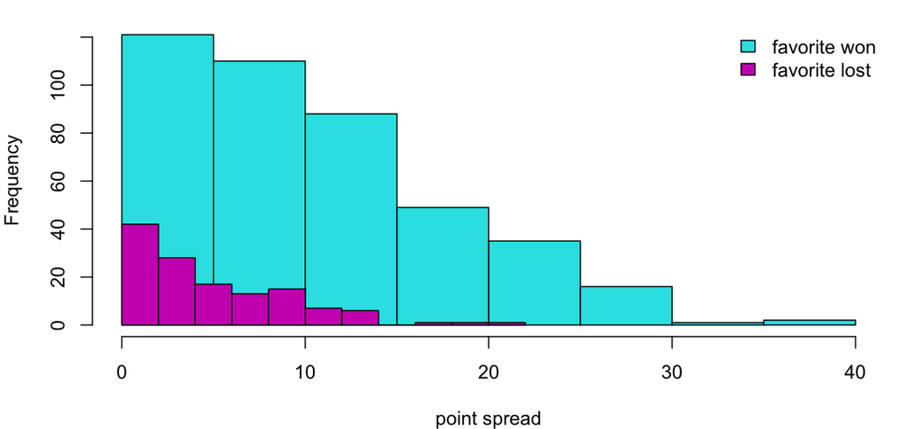

Point spread when the favorite won, turquoise, and when the favorite lost, purple

## Example: NBA Point Spread

Predicting whether the favorite wins from the point spread. No intercept: a spread of zero is a probability of one half.

- Every 1-point increase in spread raises the log-odds by 0.156.
- 4-point spread: about 65 percent. 8-point spread: about 78 percent.
- Doubling the spread does not double the probability. That is the curve on the next slide.

## What a coefficient changes

[figure not shown]

Win probability as a function of the spread in the original basketball model

$$p=\sigma(0.156s)$$

- At 4 points: about 65 percent.
- At 8 points: about 78 percent.
- The coefficient changes the log-odds. The probability does not double when the spread does.

Why doesn’t doubling the spread double the probability?

```
[0.5 0.651 0.777]
```

## LinkedIn: who becomes an executive

- About 459,000 members who worked at a top-10 consultancy between 1990 and 2010.
- About 64,000 later reached VP, CXO, or partner at a company of at least 200 people.
- Base rate about 14 percent, among people who made it into the database.
- One logit, eight features: metro region, gender, graduate school, undergraduate school, number of companies, number of job functions, number of industries, and years of experience.
- [Irwin, New York Times, 11 September 2016](https://www.nytimes.com/2016/09/11/upshot/how-to-become-a-ceo-the-quickest-path-is-a-winding-one.html).
- [Berger, Gan, and Fritzler, LinkedIn, 9 September 2016](https://www.linkedin.com/pulse/how-become-executive-guy-berger-ph-d-).

## A coefficient is a change in log-odds

| Feature | Coefficient |
| --- | --- |
| Metro region | 0.28 |
| Gender (male) | 0.31 |
| Graduate education | 1.16 |
| Undergraduate education | 0.22 |
| Company count | 0.14 |
| Function count | 0.26 |
| Industry count | −0.22 |
| Years of experience | 0.09 |

- One extra job function, 0.26, is about three years of experience.
- The graduate-school coefficient, 1.16, is about thirteen years.
- Switching industries lowers the log-odds. The writeup suggests a learning curve, or relationships left behind.

## Apply the model to three people

- Person A, about 6 percent. Male in Tulsa, undergraduate degree, one job function, three companies, three industries, fifteen years.
- Person B, about 15 percent. Male in London, top international undergraduate school, non-MBA master’s, two functions, two companies, two industries, fifteen years.
- Person C, about 63 percent. Female in New York, top undergraduate program, top MBA, four functions, four companies, one industry, fifteen years.

All three have fifteen years.

### Redesign person B

Start from person B at 15 percent. Each line is one change, holding the rest fixed.

- One industry instead of two: about 3 points.
- Top-10 U.S. undergraduate school instead of a top international school: about 3 points.
- Four companies instead of two: about 4 points.
- London to New York: about 4 points.
- Four job functions instead of two: about 8 points.
- Ten more years: about 15 points.

Taken together, the probability goes to about 81 percent. Adding the separate lifts does not give that number. The sigmoid is not linear.

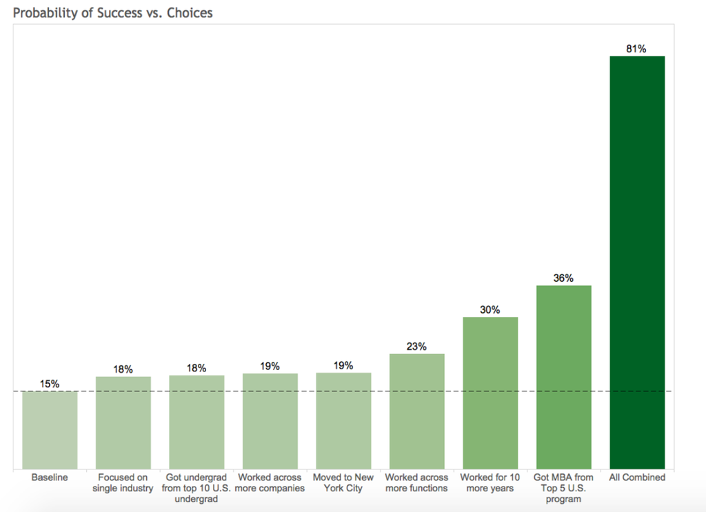

Choices and impact, starting from person B

## The loss of one observation

For an outcome $y\in\{0,1\}$ and a predicted probability $p$,

$$P(Y=y\mid p)=p^y(1-p)^{1-y}.$$

The loss is the negative log of that probability.

$$J_i=-y\log p-(1-y)\log(1-p).$$

- When $y=0$, the loss is $-\log(1-p)$.
- When $y=1$, the loss is $-\log p$.

Training minimizes the average of these losses.

[figure not shown]

The logistic function and the two Bernoulli loss curves

At $z=0$, $p=0.5$. The loss grows as $p$ moves toward the wrong outcome.

## Compare the loss at 0.60 and at 0.99

- Two models both predict that the event will happen.
- One assigns probability 0.60. The other assigns 0.99.

The event does not happen. Should they receive the same loss?

5 minutes. Paper or calculator.

- The outcome is $y=0$. The loss is $-\log(1-p)$.
- Calculate it for $p=0.60$ and for $p=0.99$.
- Now the outcome is $y=1$. The loss is $-\log p$. Which probability is cheaper?

## A sure mistake costs more

[figure not shown]

The more confident wrong prediction incurs much larger log loss

The event did not happen, so $y=0$ and the loss is $-\log(1-p)$.

- $p=0.60$ still leaves a 40 percent chance of this outcome. Loss $-\log(0.40)=0.92$.
- $p=0.99$ said the outcome was almost impossible. Loss $-\log(0.01)=4.61$.

The event did happen, so $y=1$ and the loss is $-\log p$.

- $p=0.60$: loss $-\log(0.60)=0.51$.
- $p=0.99$: loss $-\log(0.99)=0.01$.

Both numbers are above one half, so a yes-or-no score calls both predictions right, or both wrong. The loss does not. It charges the model that was sure and wrong.

## Fit the coefficients by maximum likelihood

The sample likelihood is the product of the Bernoulli probabilities, with $p_i=\sigma(x_i^\top\beta)$.

Maximizing that likelihood is the same as minimizing the sum of the losses.

$$\hat\beta=\arg\min_\beta\sum_{i=1}^n\bigl[-y_i\log p_i-(1-y_i)\log(1-p_i)\bigr].$$

- The sum is the cross-entropy. Its minimizer is the maximum likelihood estimate.
- With only an intercept, the fitted probability is the sample mean, $\hat p=\bar y$. The coefficient is $\operatorname{logit}(\bar y)$.
- With inputs, setting the derivative to zero does not give a linear system. The fit is iterative.
- The objective is convex, so that minimum is unique.

## This loss is cross-entropy

The binary loss is the cross-entropy between the observed label and the predicted probability.

$$J_i=-y\log p-(1-y)\log(1-p).$$

With more than two labels, the observation is one class. Cross-entropy is then $-\log p_y$, the negative log probability of the class that occurred.

- For class scores $z_1,\ldots,z_K$,

$$p_k=\frac{e^{z_k}}{\sum_j e^{z_j}},\qquad \sum_k p_k=1.$$

- For observed class $y$, the loss is $-\log p_y$.
- Subtracting the largest score before exponentiating leaves the probabilities unchanged and avoids overflow.

## Normalization and numerical stability

[figure not shown]

The three categorical probabilities after softmax

- Scores: $\log3,\log2,0$.
- Probabilities: $1/2,1/3,1/6$.
- First class observed: loss $\log2$.

**Does adding 1,000 change the answer mathematically?**

**Show Python: stable probabilities and stable loss**

```python
import numpy as np
from scipy.special import softmax, logsumexp
z = np.log([3., 2., 1.]) + 1000
p = softmax(z)
loss = logsumexp(z) - z[0]
print(p, loss)
assert np.allclose(p, [0.5, 1/3, 1/6])
assert np.isclose(loss, np.log(2))
```

## The next token is the same classifier

Two classes used the sigmoid of one logit, and the loss $-y\log p-(1-y)\log(1-p)$.

Many classes used the softmax of the logits, and the loss $-\log p_y$. A language model repeats that step.

- The classes are the vocabulary. The scores $z_i$ are the logits. Softmax turns them into a distribution over the next token.
- A sentence factors as a product of those one-token probabilities:
  $$P(w_1,\ldots,w_n\mid\theta)=\prod_{i=1}^n P(w_i\mid w_1,\ldots,w_{i-1},\theta).$$
- Training maximizes that likelihood. The loss is the average of $-\log p$ for the token that actually came next.

### What is different at that scale

- The vocabulary is tens of thousands of classes, so the softmax, not the sigmoid, is the expensive step.
- The training text is the sample. Maximum likelihood fits the text you gave it.
- A masked model hides a token and still pays $-\log p$ for the hidden one. The loss does not change.
- Later training from human preferences is no longer this likelihood.
- A number between zero and one is not yet a calibrated probability. Among cases assigned 0.8, check how often the event happens, on new observations.

## The representation limits the boundary

[figure not shown]

The linear logistic fit cannot enclose the inner cluster

At threshold 0.5:
$$\beta_0+\beta_1x_1+\beta_2x_2=0.$$

- Changing a threshold moves a line.
- It cannot make the line enclose a circle.
- A hidden layer can change the **features**.

**Which points would a straight boundary always struggle with?**

## A probability becomes an action

- The model supplies $p$. Act when $p\geq t$.
- The threshold $t$ depends on the cost of each error.
- A probability and an action are different outputs.

|  | Outcome 1 | Outcome 0 |
| --- | --- | --- |
| Act | True positive | False positive |
| Do not act | False negative | True negative |

$$\text{realized cost}=c_{FP}\,FP+c_{FN}\,FN$$

[figure not shown]

Expected action costs with unequal error consequences

At $p=0.3$, acting costs $1(1-p)=0.7$ and not acting costs $5p=1.5$.

**Why act when the event is less likely than not?**

## The fitted model stayed fixed

[figure not shown]

Error counts at three thresholds for the same eight probabilities and outcomes

- Same eight probabilities.
- Same eight outcomes.
- Different actions.

With $c_{FP}=1$, $c_{FN}=5$, the costs are **3, 6, and 16**.

**Which threshold wins under equal costs?**

## Supervised Learning Framework

Original code uses its source lesson’s setup and data. Saved outputs, where shown, were not rerun for this edition.

**The Prediction Problem:**

$$y = f(x)$$

**Notation:**

- $y$: output variable (response)
- $x$: input variable (predictor/feature)
- $f(x)$: predictive rule
- $\hat{y}$: predicted output value

**Training Dataset:**
$$D = (y_i,x_i)_{i=1}^n$$

**Goal:** Design rule to predict $y$ for new $x$

**Show original mermaid code 1**

```
%%| fig-width: 6.5
%%| fig-align: center
graph LR
    x --> f((f))
    f --> y
```

## Logistic Function Properties

Original code uses its source lesson’s setup and data. Saved outputs, where shown, were not rerun for this edition.

**Key properties:**

- Maps any real number to $(0,1)$
- $\sigma(0) = 0.5$
- Symmetric around 0
- Smooth S-shaped curve

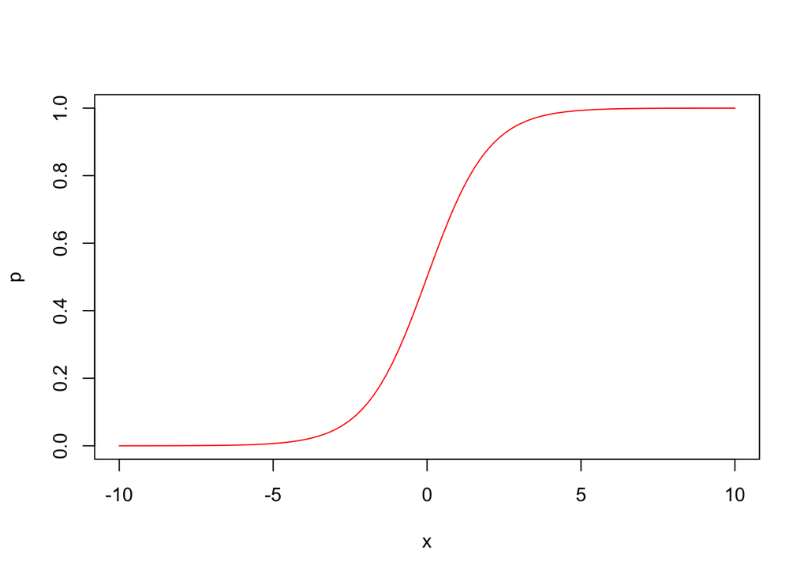

Original saved output: Logistic Function Properties

## Probit vs Logistic Models

Original code uses its source lesson’s setup and data. Saved outputs, where shown, were not rerun for this edition.

**Probit model** uses normal CDF:
$$\Phi^{-1}(p_i) = \beta^Tx_i$$

**Comparison:**

- Both give similar results in practice
- Logistic more popular (easier computation, multi-class extension)
- Probit common in economics/psychology

## Prediction and Thresholding

**Predicted probabilities:** $\hat{p}_i = \sigma(\hat{\beta}^Tx_i)$

**Binary prediction:**
$$\hat{y}_i = \begin{cases}
1 & \text{if } \hat{p}_i > \alpha \\
0 & \text{if } \hat{p}_i \leq \alpha
\end{cases}$$

**Common choice:** $\alpha = 0.5$

**Accuracy:** Proportion of correct predictions

## Data Overview

Original code uses its source lesson’s setup and data. Saved outputs, where shown, were not rerun for this edition.

Let’s start by loading and exploring the tennis match data:

```r
d = read.csv("data/tennis.csv")
dim(d)
```

Let’s look at a few columns of randomly selected five rows:

```r
d[sample(1:943,size = 5),c("Player1","Player2","Round","Result","gender","surf")]
```

- **943 matches** with **44 columns** of data
- Player names, gender, surface type, and match statistics
- Focus on **Break Points Won (BPW)** as predictor
- **Result**: Binary outcome (Player 1 wins/loses)

## Break Points Won vs Match Outcome

Final match statistics are unavailable before the match. Distinguish post-match association from pre-match forecasting. Confirm the data dictionary before interpreting BPW units.

Original code uses its source lesson’s setup and data. Saved outputs, where shown, were not rerun for this edition.

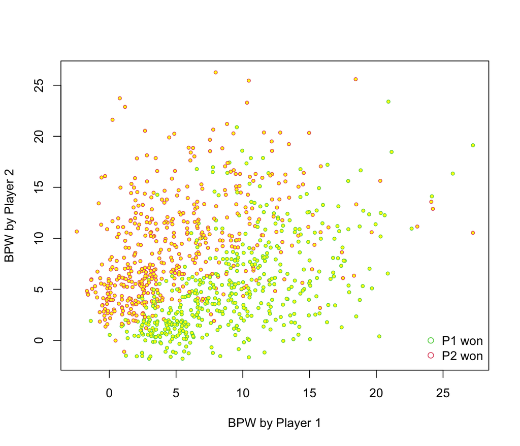

Original saved output: Break Points Won vs Match Outcome

```r
n = dim(d)[1]
plot(d$BPW.1+rnorm(n),d$BPW.2+rnorm(n), pch=21, col=d$Result+2, cex=0.6, bg="yellow", lwd=0.8,
     xlab="BPW by Player 1", ylab="BPW by Player 2")
legend("bottomright", c("P1 won", "P2 won"), col=c(3,2), pch=21, bg="yellow", bty='n')
```

- **Clear pattern**: Number of break points won strongly predicts match outcome
- This makes intuitive sense: winning break points is fundamental to winning tennis matches
- **Green dots** (Player 1 wins) cluster where Player 1 has more break points
- **Red dots** (Player 1 loses) cluster where Player 2 has more break points

## Data Preparation and Model Fitting

Original code uses its source lesson’s setup and data. Saved outputs, where shown, were not rerun for this edition.

```r
# Remove missing values
which(is.na(d$BPW.1)) # Check for NA values
d = d[-171,]; n = dim(d)[1]  # Remove row with NA

# Fit logistic regression model
library(broom)
library(knitr)
m = glm(Result ~ BPW.1 + BPW.2-1, data=d, family = "binomial")
m %>% tidy() %>% kable()
```

## Model Interpretation

The logistic regression model:
$$\log\left(\dfrac{p}{1-p}\right) = \beta_1 \cdot \text{BPW.1} + \beta_2 \cdot \text{BPW.2}$$

Where:

- $p$ = probability of Player 1 winning
- $\beta_1$ ≈ 0.40 (positive effect of Player 1’s break points)
- $\beta_2$ ≈ -0.40 (negative effect of Player 2’s break points)
- **Symmetric effects**: Winning/losing break points have equal but opposite impacts

## Predictions and Confusion Matrix

Final match statistics are unavailable before the match. Distinguish post-match association from pre-match forecasting. Confirm the data dictionary before interpreting BPW units.

Original code uses its source lesson’s setup and data. Saved outputs, where shown, were not rerun for this edition.

```r
pred <- as.integer(m$fitted.values > 0.5)
tab <- table(d$Result, pred, dnn = c("Actual", "Predicted"))
tab
cat("Model accuracy:", round(100 * sum(diag(tab)) / nrow(d), 1), "%\n")
```

## Confusion Matrix Interpretation

Final match statistics are unavailable before the match. Distinguish post-match association from pre-match forecasting. Confirm the data dictionary before interpreting BPW units.

|  | Predicted: YES | Predicted: NO |
| --- | --- | --- |
| **Actual: YES** | TPR (True Pos) | FNR (False Neg) |
| **Actual: NO** | FPR (False Pos) | TNR (True Neg) |

- **TPR**: True Positive Rate
- **FPR**: False Positive Rate
- **TNR**: True Negative Rate
- **FNR**: False Negative Rate

## Visualizing the Classification Line

Original code uses its source lesson’s setup and data. Saved outputs, where shown, were not rerun for this edition.

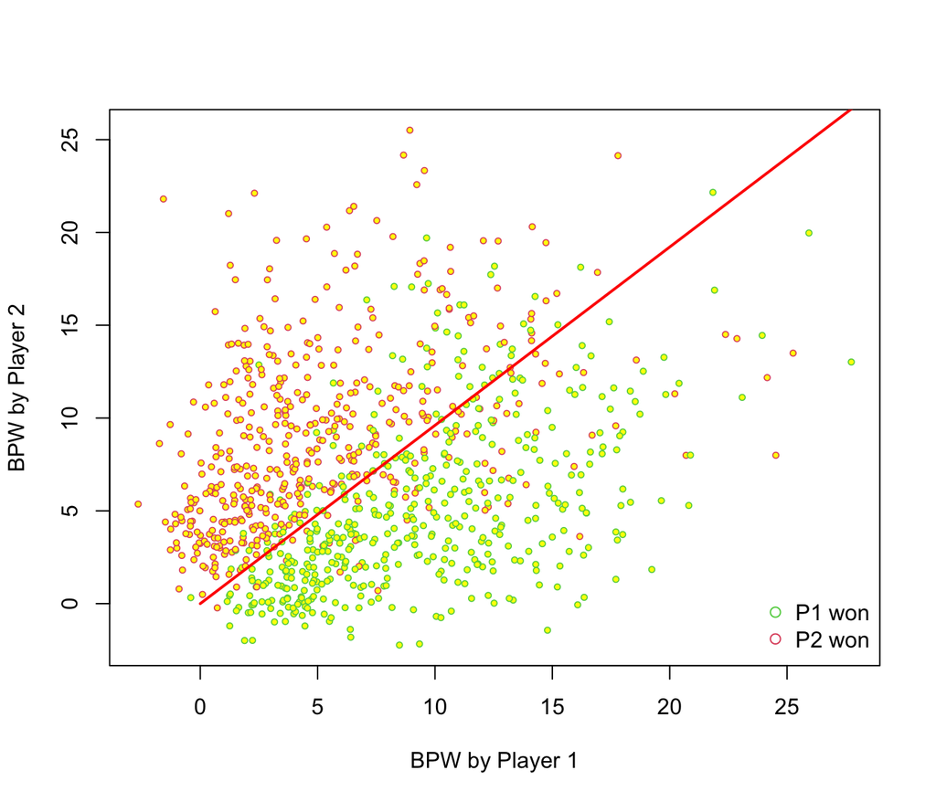

Original saved output: Visualizing the Classification Line

```r
plot(d$BPW.1+rnorm(n),d$BPW.2+rnorm(n), pch=21, col=d$Result+2, cex=0.6, bg="yellow", lwd=0.8,
     xlab="BPW by Player 1", ylab="BPW by Player 2")
legend("bottomright", c("P1 won", "P2 won"), col=c(3,2), pch=21, bg="yellow", bty='n')

# Add decision boundary
x = seq(0,30,length.out = 200)
y = -m$coefficients[1]*x/m$coefficients[2]
lines(x,y, lwd=2, col="red")
```

## Decision Boundary Mathematics

The decision boundary occurs where $p = 0.5$, meaning log-odds = 0:

$$\beta_1 x_1 + \beta_2 x_2 = 0$$

Therefore:
$$x_2 = \dfrac{-\beta_1}{\beta_2}x_1$$

Points **above the line**: Player 2 more likely to win  
Points **below the line**: Player 1 more likely to win

## Impact of Winning Break Points

Final match statistics are unavailable before the match. Distinguish post-match association from pre-match forecasting. Confirm the data dictionary before interpreting BPW units.

Original code uses its source lesson’s setup and data. Saved outputs, where shown, were not rerun for this edition.

What happens when Player 1 wins one additional break point?

```r
# Baseline probability (both players at 0 break points)
predict.glm(m, newdata = data.frame(BPW.1 = c(0), BPW.2 = c(0)), type="response")

# After Player 1 wins 1 break point
predict.glm(m, newdata = data.frame(BPW.1 = c(1), BPW.2 = c(0)), type="response")
```

**Effect**: Probability increases from **50%** to **60%**

## Odds Ratio Calculation

Final match statistics are unavailable before the match. Distinguish post-match association from pre-match forecasting. Confirm the data dictionary before interpreting BPW units.

Original code uses its source lesson’s setup and data. Saved outputs, where shown, were not rerun for this edition.

```r
# Odds ratio for one additional break point
exp(0.4019)
```

**Interpretation**: Each additional break point won increases the odds of winning by a factor of **1.5**

Mathematical derivation:
$$\dfrac{p}{1-p} = 1.5 \Rightarrow p = 0.6$$

## Cumulative Effect

Final match statistics are unavailable before the match. Distinguish post-match association from pre-match forecasting. Confirm the data dictionary before interpreting BPW units.

Original code uses its source lesson’s setup and data. Saved outputs, where shown, were not rerun for this edition.

What about winning 3 more break points than the opponent?

```r
predict.glm(m, newdata = data.frame(BPW.1 = c(0), BPW.2 = c(0)), type="response")
predict.glm(m, newdata = data.frame(BPW.1 = c(3), BPW.2 = c(0)), type="response")
```

**Result**: Probability increases by **27 percentage points** (from 50% to 77%)

[figure not shown]

Original saved output: Cumulative Effect

## Research Question

Original code uses its source lesson’s setup and data. Saved outputs, where shown, were not rerun for this edition.

> *“Are women’s matches less predictable than men’s matches?”*

This is a common claim in tennis commentary. We can test this using model residuals.

```r
library(dplyr)
d$res = abs(m$residuals)
outlind = which(d$res<2)  # Remove extreme outliers
boxplot(d$res[outlind] ~ d$gender[outlind], col=c(2,3), xlab="Gender", ylab="Residual")
```

**Larger residuals** = **Less accurate predictions** = **More unpredictable matches**

## Statistical Test

Original code uses its source lesson’s setup and data. Saved outputs, where shown, were not rerun for this edition.

```r
men = d %>% filter(res<2, gender=="M") %>% pull(res)
women = d %>% filter(res<2, gender=="W") %>% pull(res)
t.test(men, women, alternative = "two.sided") %>% tidy() %>% kable()
```

- **Mean difference**: 0.07 (women have higher residuals)
- **t-statistic**: -4.7 (highly significant)
- **p-value**: < 0.001

**Conclusion**: The conventional wisdom is **statistically supported** - women’s tennis matches are indeed less predictable based on break points won.

## Key Findings

1. **Strong Predictor**: Break points won is highly predictive of match outcomes
2. **Symmetric Effects**: Winning/losing break points have equal magnitude effects
3. **Quantified Impact**: Each break point increases winning odds by 50%
4. **High Accuracy**: Model achieves ~88% prediction accuracy
5. **Gender Difference**: Women’s matches are significantly less predictable
- **Logistic regression** effectively models binary sports outcomes
- **Confusion matrices** provide comprehensive performance evaluation
- **Residual analysis** can reveal interesting domain-specific patterns
- **Statistical testing** validates common beliefs with data

## Generating Non-linearly Separable Data

Original code uses its source lesson’s setup and data. Saved outputs, where shown, were not rerun for this edition.

Let’s create a circular dataset to demonstrate the kernel trick:

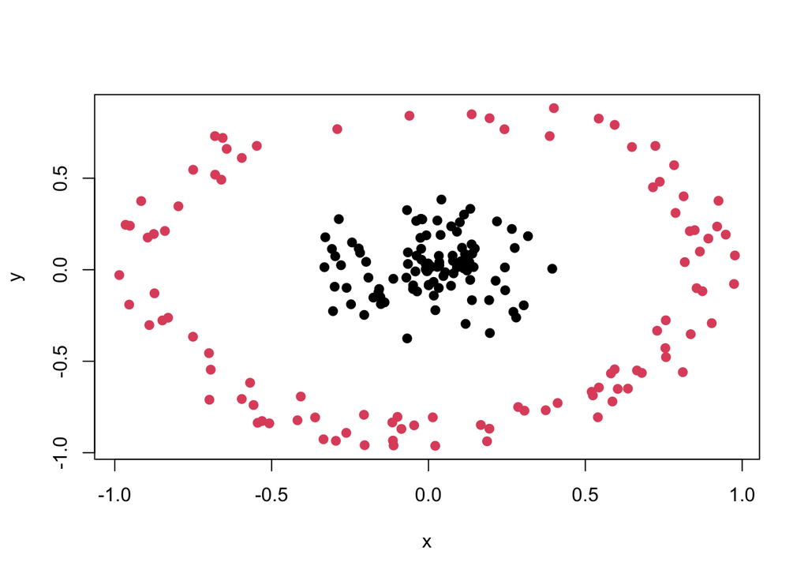

Original saved output: Generating Non-linearly Separable Data

## The Kernel Trick Solution

The data in the circle-data plot is clearly not linearly separable. However, if we map it to a three-dimensional space using the transformation:
$$\begin{aligned}
\phi: R^{2} & \longrightarrow R^{3} \\
\left(x_{1}, x_{2}\right) & \longmapsto\left(z_{1}, z_{2}, z_{3}\right)=\left(x_{1}^{2}, \sqrt{2} x_{1} x_{2}, x_{2}^{2}\right),
\end{aligned}$$
and attempt to linearly separate the transformed data, the decision boundaries become hyperplanes in $R^{3}$, expressed as $\omega^{T} z + b = 0$. In terms of the original variables $x$, these boundaries take the form:
$$\omega_{1} x_{1}^{2} + \omega_{2} \sqrt{2} x_{1} x_{2} + \omega_{3} x_{2}^{2} = 0,$$
which corresponds to the equation of an ellipse. This demonstrates that we can apply a linear algorithm to transformed data to achieve a non-linear decision boundary with minimal effort.

## The Gram Matrix and Kernels

Now, consider what the algorithm is actually doing. It relies solely on the Gram matrix $K$ of the data. Once $K$ is computed, the original data can be discarded:
$$\begin{aligned}
K & = \left[\begin{array}{ccc}
x_{1}^{T} x_{1} & x_{1}^{T} x_{2} & \cdots \\
x_{2}^{T} x_{1} & \ddots & \\
\vdots & &
\end{array}\right]_{n \times n} = X X^{T}, \\
\text{where} \quad X & = \left[\begin{array}{c}
x_{1}^{T} \\
\vdots \\
x_{n}^{T}
\end{array}\right]_{n \times d}.
\end{aligned}$$
Here, $X$, which contains all the data, is referred to as the design matrix.

## Kernel Matrix After Transformation

When we map the data using $\phi$, the Gram matrix becomes:
$$K = \left[\begin{array}{ccc}
\phi\left(x_{1}\right)^{T} \phi\left(x_{1}\right) & \phi\left(x_{1}\right)^{T} \phi\left(x_{2}\right) & \cdots \\
\phi\left(x_{2}\right)^{T} \phi\left(x_{1}\right) & \ddots & \\
\vdots & &
\end{array}\right].$$
Let us compute these inner products explicitly. For vectors $r$ and $s$ in $R^{3}$ corresponding to $a$ and $b$, respectively:
$$\begin{aligned}
\langle r, s \rangle & = r_{1} s_{1} + r_{2} s_{2} + r_{3} s_{3} \\
& = a_{1}^{2} b_{1}^{2} + 2 a_{1} a_{2} b_{1} b_{2} + a_{2}^{2} b_{2}^{2} \\
& = (a_1 b_1 + a_2 b_2)^2 \\
& = \langle a, b \rangle^{2}.
\end{aligned}$$

where $a = (a_1, a_2)$ and $b = (b_1, b_2)$ are the original 2D vectors, and $r = \phi(a)$ and $s = \phi(b)$ are their transformations in $R^3$.

## Visualizing the Transformation

Original code uses its source lesson’s setup and data. Saved outputs, where shown, were not rerun for this edition.

Let’s implement and visualize the transformation:

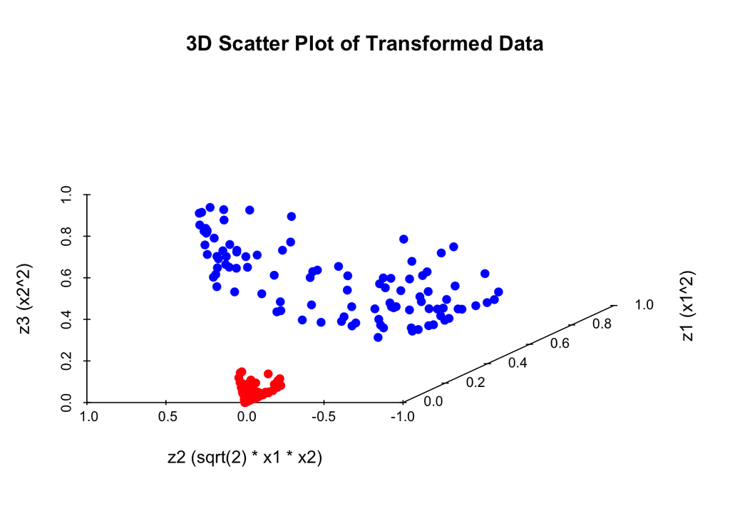

Original saved output: Visualizing the Transformation

## Tree Example

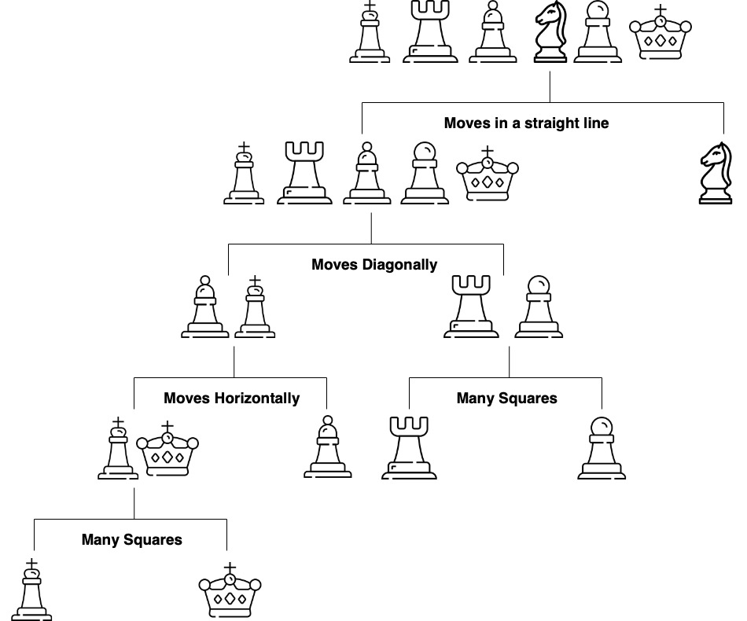

Figure 1: Elementary tree scheme; visualization of the splitting process

### Tree Building Process

**Three main components:**

1. **Splitting:** Divide data based on feature values to create homogeneous subsets
2. **Stopping:** Decide when to stop splitting (prevent overfitting)
3. **Pruning:** Remove nodes that don’t improve accuracy

**Goal:** Find regions $R_1, R_2, \ldots, R_J$ that minimize:
$$\text{RSS} = \sum_{j=1}^J\sum_{i \in R_j}(y_i - \bar{y}_j)^2$$

## Recursive Binary Splitting (CART)

**Algorithm:** Top-down, greedy approach

**At each step, find optimal split:**

- Choose feature $j$ and split point $s$
- Create regions: $R_1(j,s) = \{x \mid x_j < s\}$ and $R_2(j,s) = \{x \mid x_j \geq s\}$

**Optimization problem:**
$$\min_{j,s}\left[ \sum_{i:x_i\in R_1}(y_i - \bar{y}_1)^2 + \sum_{i:x_i \in R_2}(y_i - \bar{y}_2)^2\right]$$

**Prediction in region $R_j$:**
$$f(x) = \bar{y}_j = \text{Average}(y_i \mid x_i \in R_j)$$

## Diamond Example

- Imagine you’re a jewelry appraiser determining a diamond’s value
- You follow a series of questions: Is the carat weight above 1.0?
- If yes, is the clarity VS1 or better?
- Each question leads to another, creating a decision path
- This mirrors our natural decision-making process

## Decision Trees: The Concept

Decision trees create a flowchart of if-then rules that:

- Mirror human decision-making processes
- Create interpretable prediction rules
- Handle non-linear relationships naturally
- Capture feature interactions automatically

## Our Journey Today

We’ll explore tree-based models using the classic diamonds dataset:

- **53,940 diamonds** with prices and attributes
- Start with **simple decision trees**
- Progress to **ensemble methods** (random forests, gradient boosting)
- Develop insights into when and how to use these algorithms
- Learn to avoid common pitfalls

## The Diamonds Dataset

| Variable | Description | Values |
| --- | --- | --- |
| `carat` | Weight of the diamond | Numeric |
| `cut` | Quality of the cut | Fair, Good, Very Good, Premium, Ideal |
| `color` | Color of the diamond | J, I, H, G, F, E, D |
| `clarity` | Clarity of the diamond | I1, SI2, SI1, VS2, VS1, VVS2, VVS1, IF |
| `depth` | Depth of the diamond | Numeric |
| `table` | Width of the diamond’s table | Numeric |

## Loading the Data

Original code uses its source lesson’s setup and data. Saved outputs, where shown, were not rerun for this edition.

## Price vs Carat Relationship

Original code uses its source lesson’s setup and data. Saved outputs, where shown, were not rerun for this edition.

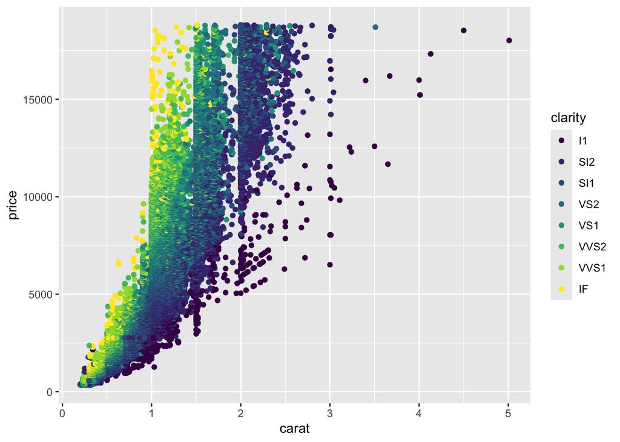

Original saved output: Price vs Carat Relationship

## Log-Transformed Relationships

Original code uses its source lesson’s setup and data. Saved outputs, where shown, were not rerun for this edition.

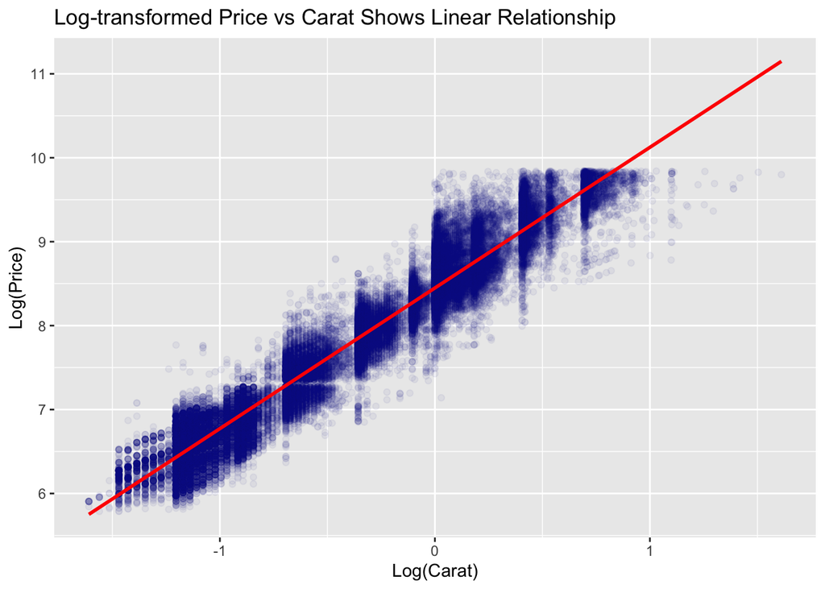

Original saved output: Log-Transformed Relationships

## Beyond Carat: The Role of Clarity

Original code uses its source lesson’s setup and data. Saved outputs, where shown, were not rerun for this edition.

Although carat is the most important factor, it’s not the only one:

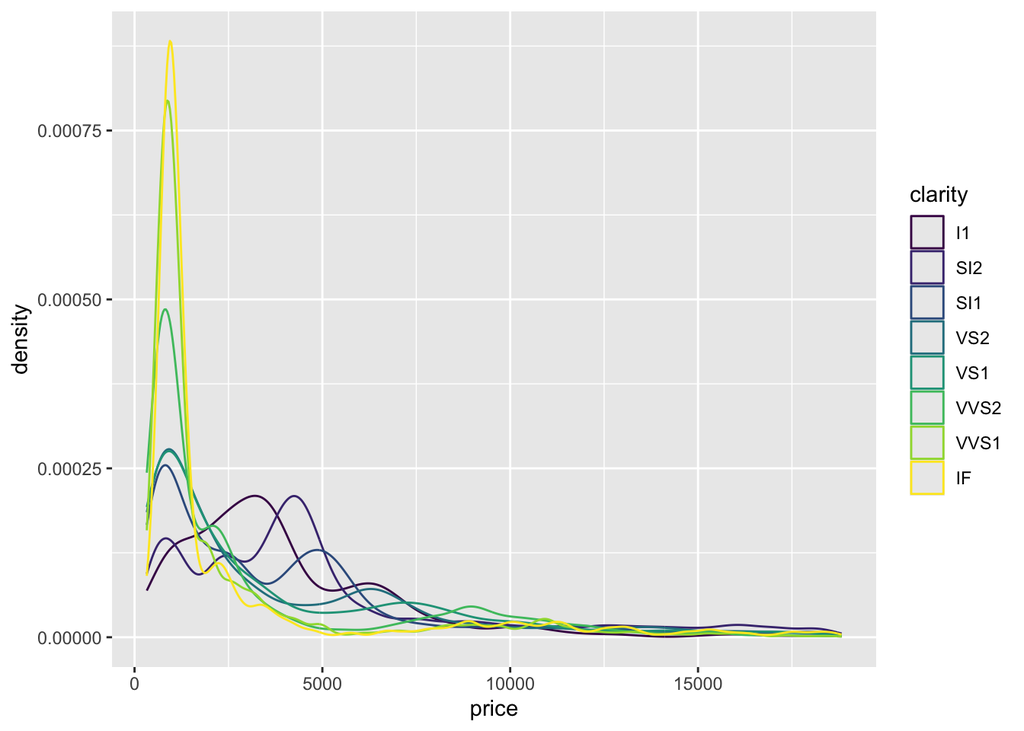

Original saved output: Beyond Carat: The Role of Clarity

## Building Our First Decision Tree

Original code uses its source lesson’s setup and data. Saved outputs, where shown, were not rerun for this edition.

Let’s start simple with just two predictors:

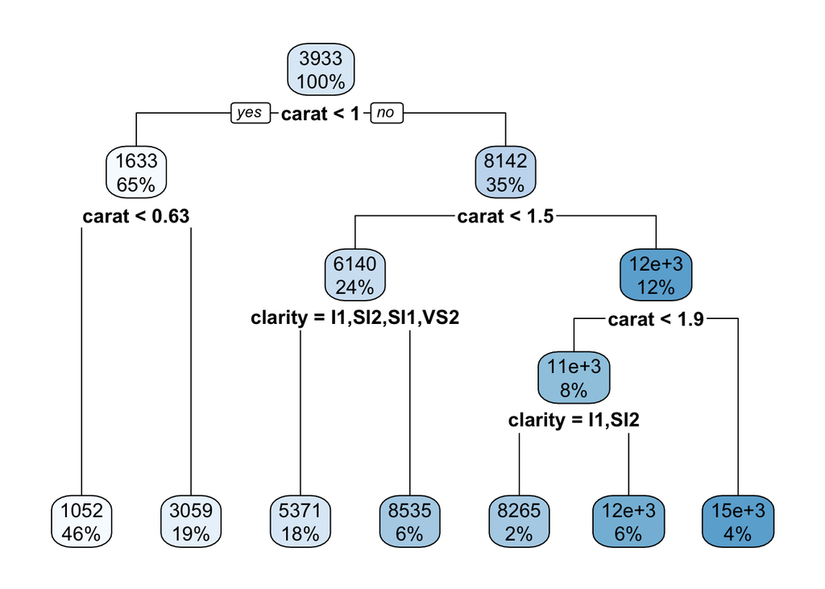

Original saved output: Building Our First Decision Tree

## Visualizing the Feature Space

Original code uses its source lesson’s setup and data. Saved outputs, where shown, were not rerun for this edition.

**Observation**: Clarity becomes most important around 1 carat level

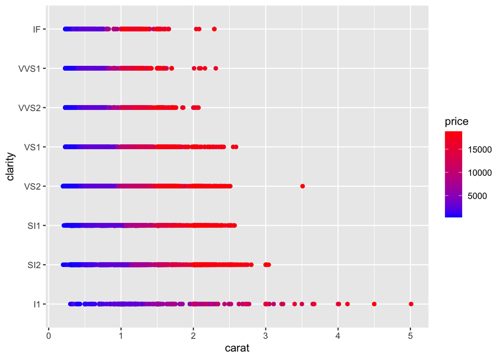

Original saved output: Visualizing the Feature Space

## Tree Prediction Regions

Original code uses its source lesson’s setup and data. Saved outputs, where shown, were not rerun for this edition.

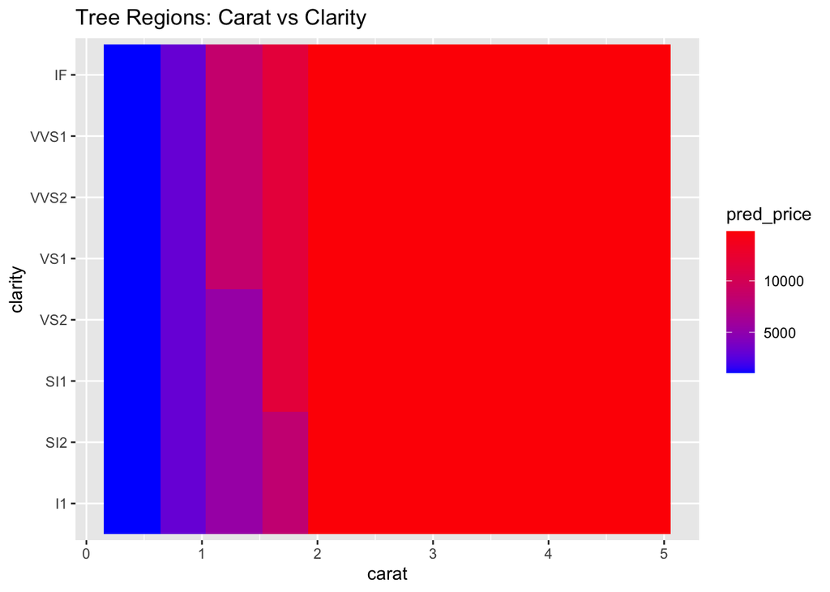

Original saved output: Tree Prediction Regions

## Understanding Prediction Regions

The visualization shows several key patterns:

- **Vertical bands** indicate carat as strongest predictor
- **Non-linear patterns** that linear models would miss
- **Rectangular regions** with sharp boundaries
- **Rate of price increase** varies across clarity levels

**Note**

**The Algorithm**:

1. Divide predictor space into $J$ distinct, non-overlapping regions: $R_1, R_2, \ldots, R_J$
2. For every observation in region $R_j$, make the same prediction
3. Prediction = mean of response values for training observations in $R_j$

## Next Steps

From here we’ll explore:

- **Tree construction algorithms** (recursive binary splitting)
- **Pruning techniques** to avoid overfitting
- **Ensemble methods** (Random Forests, Gradient Boosting)
- **Hyperparameter tuning** for optimal performance
- **Model interpretation** and feature importance

**Key insights:**

- Primary split on carat (most important predictor)
- Secondary splits on clarity
- Rectangular prediction regions
- Natural handling of feature interactions

## Example: Boston Housing

For Saratoga use the revised 1,728-row fit. Its intercept is extrapolation, not an identified land value. Legacy dataset with a problematic constructed racial variable. Retained for historical critique, not recommended as an unqualified classroom benchmark.

Original code uses its source lesson’s setup and data. Saved outputs, where shown, were not rerun for this edition.

**Results:** Step function fit with 7 regions, clear visualization of decision boundaries

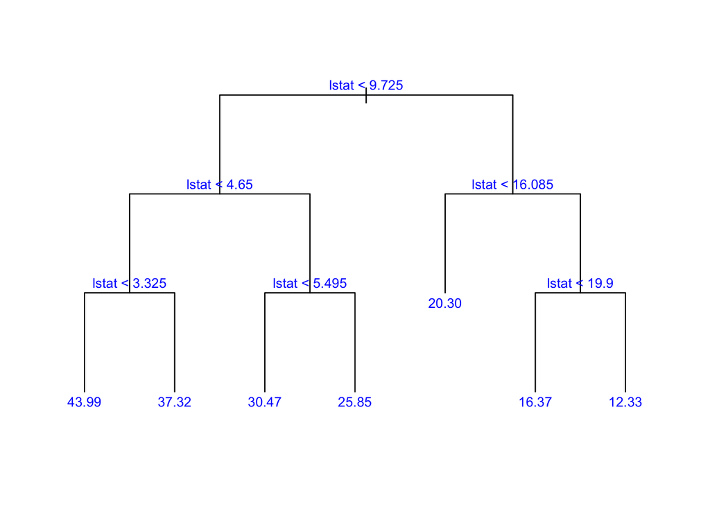

Original saved output: Example: Boston Housing

## Random Forest Example

Original code uses its source lesson’s setup and data. Saved outputs, where shown, were not rerun for this edition.

**Variable importance:** Total decrease in node impurity when splitting on each variable, averaged over all trees

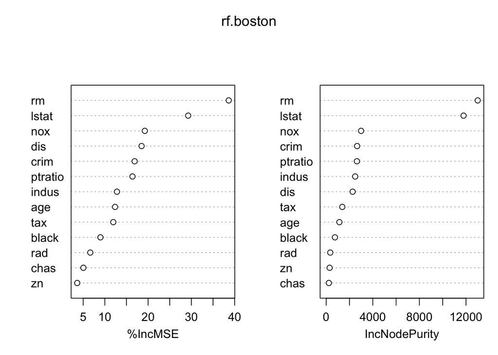

Original saved output: Random Forest Example

## Team practice

- State the proposed project’s prediction time, available inputs, target, and action.
- Explain who bears a false positive and a false negative.
- Name a simple baseline. Identify a result that would make you reconsider the project question.

What does a logit of zero mean?

Why is a probability of 0.99 costly when the event fails to happen?

What changes in the fitted parameters when you change only the threshold?

What happens to the preferred threshold when false negatives become more costly?

## Which fit would you use?

Validation, generalization, and leakage.

[figure not shown]

Three fitted polynomial models

Choose before seeing new observations. State the evidence you wish you had.

$$\hat\theta=\arg\min_\theta\frac1n\sum_i J_i(\theta).$$

- A small loss on the same observations answers a limited question.
- We need evidence about observations that did not participate in fitting or selecting the model.

## Three roles for data

| Data | Job |
| --- | --- |
| Training | Fit parameters and preprocessing |
| Validation | Choose features, models, and tuning settings |
| Test | Evaluate the fixed choice |

Selecting a model is a use of data, even when no coefficient is fitted directly to those data.

## A baseline gives the score meaning

- For regression, predict the **training mean**.
- Keep validation outcomes out of that estimate.
- Compare all models on the same observations and metric.

```python
import numpy as np
y_train = np.array([1., 3., 3.])
y_validation = np.array([2., 4.])
baseline = y_train.mean()
mse = np.mean((y_validation - baseline)**2)
print(baseline, mse)       # 2.333... and 1.444...
assert np.isclose(mse, 13/9)
```

**Why would using the validation mean change the experiment?**

$$\operatorname{MSE}=\frac1m\sum_{i=1}^m(y_i-\hat y_i)^2.$$

$m$ is the number of observations being evaluated.

- RMSE is $\sqrt{\operatorname{MSE}}$, in the units of the response.
- The metric must reflect the question. A large error counts strongly under squared loss.

[figure not shown]

Training and validation error for the same polynomial fits

The ranking on the training observations need not be the ranking on the validation observations.

## A random split can answer the wrong question

**Prediction time: before a tennis match starts.**

| Proposed input | Available then? |
| --- | --- |
| Player identities and scheduled surface | Yes |
| Past-match summaries computed before today | Potentially |
| Today’s final break-point statistics | No |
| Today’s final score | No |

- A random split does not repair an input that arrives too late.
- Separating time or players must match the intended use.

**Would your answer change for a post-match explanation?**

## The feature used the answer

[figure not shown]

Match outcomes plotted against final recorded tennis statistics

**Original tennis example**

- A striking pattern is visible.
- Both axes use statistics recorded during the match.
- Those values are unavailable before the match.

**Good explanation after the event, or a usable prediction before it?**

## Preprocessing also learns from data

- Scaling estimates a mean and a spread.
- Learn them on training observations only.
- Reuse that transformation on validation observations.

**Show Python: fit on training, transform validation**

```python
import numpy as np
from sklearn.preprocessing import StandardScaler
train = np.array([[1.], [2.], [3.]])
validation = np.array([[100.]])
scaler = StandardScaler().fit(train)
print(scaler.mean_, scaler.transform(validation))
assert np.allclose(scaler.mean_, [2.])
```

**If you fitted the scaler again on the single validation case, what would happen?**

## Cross-validation repeats a fitting experiment

[figure not shown]

Five folds take turns as validation data

- Fit on four folds. Score on the fifth.
- Repeat for every proposed setting.
- **10 settings × 5 folds = 50 fits**, plus the final refit.

**What does parallel execution change: elapsed time, total work, or both?**

A team tries twenty models and reports the smallest test error.

What did the test set become?

It participated in selection. A fresh evaluation is needed for the selected procedure.

## The betting example: what would convince us?

| Check | Question for this example |
| --- | --- |
| Prediction time | Were those odds available when the choice was made? |
| Selection | Did the same results choose and evaluate the rule? |
| Baseline | Does the comparison use a comparable opportunity set and stake? |
| Execution | Could the quoted bets actually be placed? |

**Which check would you run before trusting the blue curve?**

[Kaunitz, Zhong, and Kreiner (2017)](https://arxiv.org/abs/1710.02824): historical simulations, paper trading, and a smaller real-money experiment.

## The original hard function: outside the observed range

[figure not shown]

Polynomial approximation inside and outside the observed range

- $f(x)=1/(1+25x^2)$, observed on the shaded interval $[-2,2]$.
- Predictions outside that range are **extrapolation**.
- A better fit inside need not behave sensibly outside. Curves leaving the panel are clipped.

**Show Python: a degree-20 fit at an unobserved input**

```python
import numpy as np
x = np.linspace(-2, 2, 401)
f = lambda x: 1 / (1 + 25*x*x)
fit = np.polynomial.Polynomial.fit(x, f(x), deg=20)
print("At x=2.5:", fit(2.5), "true:", f(2.5))
```

## ROC Example (Defualt Data Set)

Original code uses its source lesson’s setup and data. Saved outputs, where shown, were not rerun for this edition.

Build logistic regression model

## ROC Curve

Original code uses its source lesson’s setup and data. Saved outputs, where shown, were not rerun for this edition.

Define the ROC curve function

## Plot the ROC Curve

Original code uses its source lesson’s setup and data. Saved outputs, where shown, were not rerun for this edition.

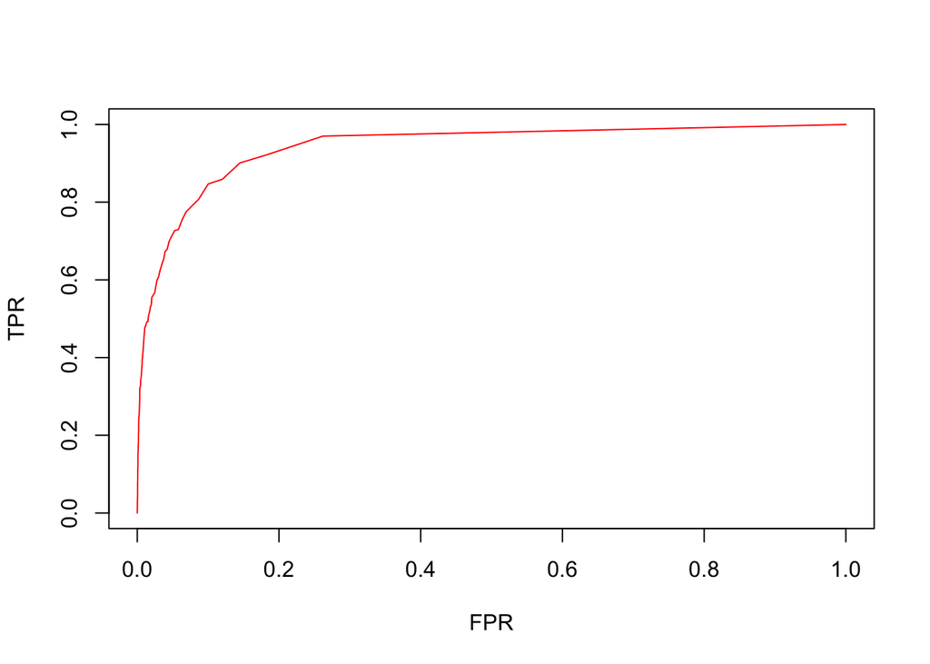

Original saved output: Plot the ROC Curve

## The Trading Algorithm Challenge

**The Scenario:** You’re a quant at a trading firm with a new algorithm that outperformed the state-of-the-art on historical data.

**The Question:**

- Did you discover a truly dominant strategy?
- Or did you just get lucky?

**Sequential Analysis:**

- Bayesian methods
- Decides how long to wait for sufficient evidence
- Balances exploration vs exploitation

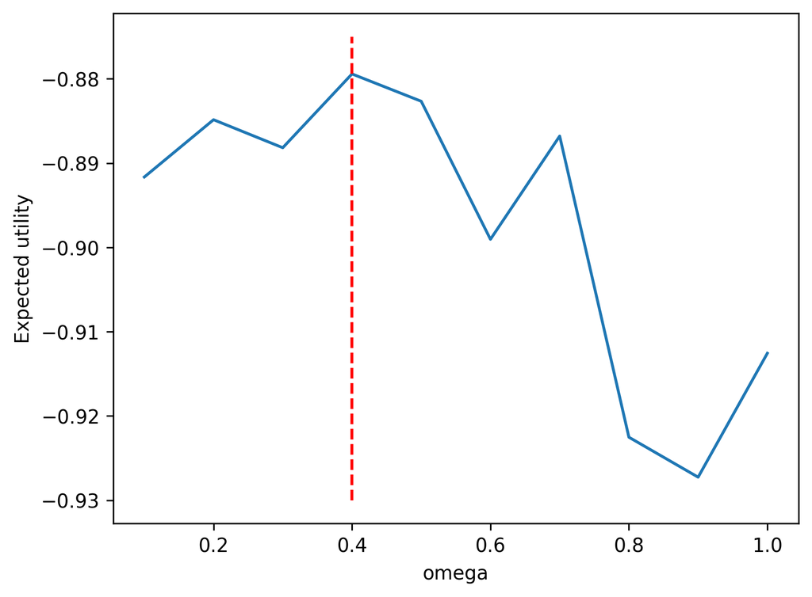

Trading

## SimCity AB Test

[figure not shown]

SimCity Original

[figure not shown]

SimCity Variation

### Electronic Arts SimCity 5: AB Testing Success

**The Problem:**

- 1.1M copies sold in first 2 weeks
- 50% digital downloads
- Promotional banner not driving expected pre-orders

**The Test:**

- Original: Banner with promotional offer
- Variation: No promotional messaging

**The Surprising Result:**

- **43.4% more purchases** with no offer!
- People just wanted to buy the game
- No extra incentive necessary

## SimCity AB Test: Statistical Analysis

Original code uses its source lesson’s setup and data. Saved outputs, where shown, were not rerun for this edition.

**Test Setup:**

- Pink background: 40% purchase rate, 500 visitors
- Black background: 30% purchase rate, 550 visitors

**Result:** Pink background significantly outperforms!

## The Black Monday Event

Original code uses its source lesson’s setup and data. Saved outputs, where shown, were not rerun for this edition.

**October 19, 1987:** S&P 500 dropped -21.76%

**Historical Context:** - Prior monthly returns: 1.2% mean, 4.3% volatility - Distribution: $X \sim N(1.2, 4.3^2)$

**Z-Score Calculation:**
$$Z = \frac{X-\mu}{\sigma} = \frac{-0.2176 - 0.012}{0.043} = -5.34$$

**Interpretation:**

An extremely rare occurrence!

## Patriots Coin Toss: Confidence Interval

Original code uses its source lesson’s setup and data. Saved outputs, where shown, were not rerun for this edition.

**Conclusion:** Since 0.5 is outside the confidence interval, we have evidence that coin tosses were not fair.

## The Question: Is Yawning Contagious?

**2006 Discovery Channel Experiment**

- 50 participants total
- 34 in experimental group (interviewer yawned)
- 16 in control group (no yawn)

**Results:**

- Experimental: 10/34 yawned (29.4%)
- Control: 4/16 yawned (25.0%)
- Difference: 4.4%

**Mythbusters Conclusion:** Yawning is contagious!

**But is this statistically significant?**

## Mythbusters: Statistical Analysis

Original code uses its source lesson’s setup and data. Saved outputs, where shown, were not rerun for this edition.

**Statistical Conclusion:** Large overlap, CI contains 0 - no evidence of difference!

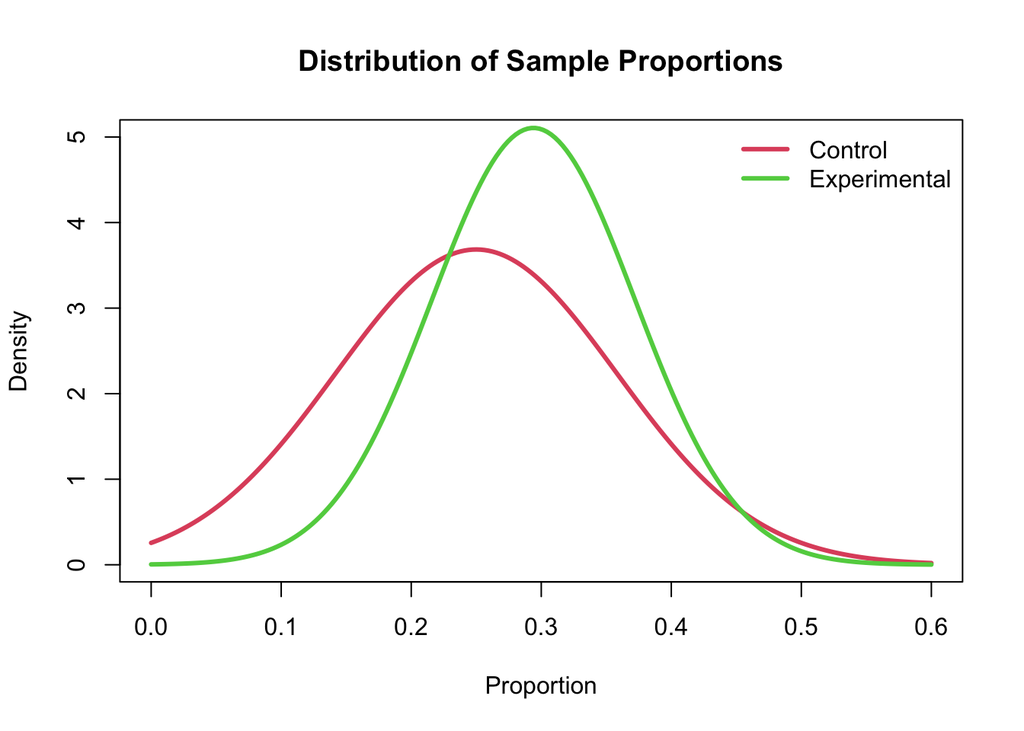

Original saved output: Mythbusters: Statistical Analysis

## Google Search Algorithm Test

**The Experiment:**

- Test effectiveness of new search algorithm
- Measure: Click-through rate on search results
- Random assignment to Algo 1 or Algo 2
- 2500 requests per algorithm

|  | Algo1 | Algo2 |
| --- | --- | --- |
| Success | 1755 | 1818 |
| Failure | 745 | 682 |
| Total | 2500 | 2500 |

**Estimated Success Rates:**

- Algo 1: $\hat{p}_1 = 0.702$
- Algo 2: $\hat{p}_2 = 0.727$

## Google Search: Confidence Intervals

Original code uses its source lesson’s setup and data. Saved outputs, where shown, were not rerun for this edition.

## The Challenge

Original code uses its source lesson’s setup and data. Saved outputs, where shown, were not rerun for this edition.

**Pepsi’s Claim:** “More than half of Diet Coke drinkers prefer Diet Pepsi”

- **The Test:** Double-blind experiment with 100 drinkers
- **Result:** 56 favor Pepsi
- **Hypothesis Setup:**
  - $H_0: p = 0.5$ (no preference)
  - $H_1: p > 0.5$ (Pepsi preferred)

**Conclusion:** $p=0.5$ is in the CI - Pepsi’s claim is not supported!

## Avonex: FDA vs Biogen

Historical teaching case. Clinical or company claims require source review before reuse as current evidence. The supplied numbers are not clinical guidance.

### The Dispute

Original code uses its source lesson’s setup and data. Saved outputs, where shown, were not rerun for this edition.

**Biogen’s Claim:** “95% patient satisfaction rate” **FDA Investigation:** 60% satisfaction in random sample of 75 patients **Question:** Who is right?

**Hypothesis Test:** - $H_0: p = 0.95$ (Biogen innocent) - $H_1: p < 0.95$ (FDA right) - $\alpha = 0.01$ (1% significance level)

**Result:** Z = -14, p-value ≈ 0 - FDA is right, Biogen is wrong!

## Pfizer Viagra: Safety Concerns

Historical teaching case. Clinical or company claims require source review before reuse as current evidence. The supplied numbers are not clinical guidance.

### The Safety Question

Original code uses its source lesson’s setup and data. Saved outputs, where shown, were not rerun for this edition.

**1998 Data:**

- 6 million Viagra users: 77 deaths from coronary problems
- 1.5 million non-users: 11 deaths from coronary problems **Pfizer’s Claim:** Death rate no higher than general population

**Statistical Analysis:**

- Viagra rate: $\hat{p}_1 = 77/6,000,000 = 0.00001283$
- Control rate: $\hat{p}_2 = 11/1,500,000 = 0.00000733$

**Result:** CI doesn’t contain 0 - evidence of higher death rate with Viagra!

## Nobel Prize Discovery (1904)

Original code uses its source lesson’s setup and data. Saved outputs, where shown, were not rerun for this edition.

**The Experiment:**

- **Method 1:** Remove oxygen from air, measure remaining gas density
- **Method 2:** Prepare pure nitrogen by chemical decomposition
- **Question:** Are the densities the same?

## Rayleigh’s Discovery: Statistical Test

Original code uses its source lesson’s setup and data. Saved outputs, where shown, were not rerun for this edition.

**The Discovery:** - Z-score ≈ 20 (20-sigma event!) - Massive statistical significance - **Argon was discovered** - the “inert” gas in air!

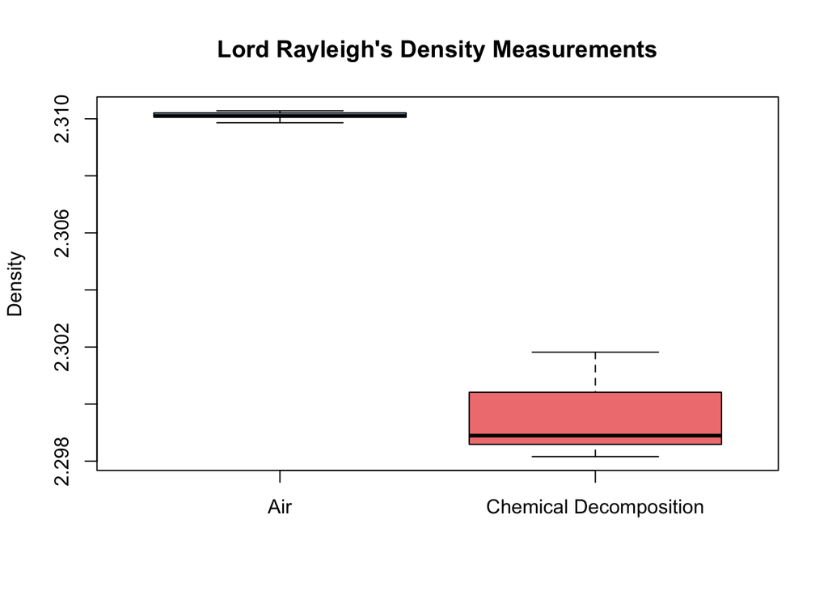

Original saved output: Rayleigh’s Discovery: Statistical Test

## The Bias-Variance Trade-off

Original code uses its source lesson’s setup and data. Saved outputs, where shown, were not rerun for this edition.

## The Hard Function Example

Inspect the actual experiment. A named regime or curve is not a universal result. Separate interpolation, noise fitting, extrapolation, basis conditioning and floating-point effects.

Original code uses its source lesson’s setup and data. Saved outputs, where shown, were not rerun for this edition.

**Approximating a challenging function:**
$$f(x) = \frac{1}{1+25x^2}$$

## Hard Function: Key Insights

Inspect the actual experiment. A named regime or curve is not a universal result. Separate interpolation, noise fitting, extrapolation, basis conditioning and floating-point effects.

- **Training Region:** $x \in [-2,2]$
- **Test Region:** $x \in [-3,-2) \cup (2,3]$

**Observations:**

- Linear model: poor fit everywhere
- Degree 2: captures some curvature
- Degree 5: reasonable approximation
- **Degree 20: catastrophic overfitting!**

**Lesson:** High-degree polynomials fit training data perfectly but fail completely on test data

**Einstein’s Principle:** “A model should be simple, but not simpler”

**Solution:** Regularization!

## Data Quality Challenges

- **Missing values**: Systematic vs random patterns
- **Measurement errors**: Sensor noise, human error
- **Sampling bias**: Non-representative samples
- **Label noise**: Incorrect classifications
- **Temporal drift**: Changing data distributions

**Solutions:**

- Data cleaning pipelines
- Robust estimation methods
- Uncertainty quantification
- Professional annotation services (Scale AI, Toloka)

## Model Explainability

**Why Explainability Matters:**

- Healthcare: diagnosis reasoning
- Finance: loan decisions
- Legal: GDPR compliance
- Science: understanding mechanisms

**Modern Techniques:**

- LIME: local explanations
- SHAP: unified framework
- Attention mechanisms
- Gradient-based methods
- Counterfactual explanations

## Session Structure (45 minutes)

The numerical Bayes exercise is illustrative. Do not infer that the named deployed system uses this exact probabilistic architecture.

1. **Quick Context (5 min)** - Introduction to Bayesian Health and their approach
2. **Small Group Brainstorm (10 min)** - Analyze a clinical scenario
3. **Round Table Reporting (15 min)** - Share insights and debate approaches
4. **Instructor Wrap-Up (15 min)** - Technical deep dive and reflection

## Today’s Focus

The numerical Bayes exercise is illustrative. Do not infer that the named deployed system uses this exact probabilistic architecture.

**How can Bayesian methods transform healthcare from reactive to proactive?**

[figure not shown]

*From MYCIN’s rule-based approach in the 1970s to modern Bayesian AI*

## The Problem: Information Overload in Healthcare

Historical teaching case. Clinical or company claims require source review before reuse as current evidence. The supplied numbers are not clinical guidance. The numerical Bayes exercise is illustrative. Do not infer that the named deployed system uses this exact probabilistic architecture.

Healthcare generates massive amounts of data:

- Electronic Health Records (EHRs)
- Lab results updated continuously
- Vital signs monitored in real-time
- Imaging studies
- Clinical notes

**But clinicians are overwhelmed and critical events are missed**

The numerical Bayes exercise is illustrative. Do not infer that the named deployed system uses this exact probabilistic architecture.

How do we transform raw healthcare data into actionable insights that save lives?

## Bayesian Health: Company Overview

Historical teaching case. Clinical or company claims require source review before reuse as current evidence. The supplied numbers are not clinical guidance. The numerical Bayes exercise is illustrative. Do not infer that the named deployed system uses this exact probabilistic architecture.

**Founded by:** Dr. Suchi Saria (Johns Hopkins)

**Mission:** Transform healthcare data into clinical insights using adaptive AI

**Key Innovation:** Active Clinical Awareness platform

**Approach:** Bayesian probabilistic models for: - Early warning systems - Sepsis detection - Pressure ulcer prevention - Clinical deterioration prediction

**Recent Recognition:**

- Time Best Inventions 2024
- BioTech AI Company of the Year 2023
- Women In AI Entrepreneur 2023

**Clinical Deployment:** Cleveland Clinic system-wide expansion

## Why Bayesian Methods for Healthcare?

Historical teaching case. Clinical or company claims require source review before reuse as current evidence. The supplied numbers are not clinical guidance. The numerical Bayes exercise is illustrative. Do not infer that the named deployed system uses this exact probabilistic architecture.

Original code uses its source lesson’s setup and data. Saved outputs, where shown, were not rerun for this edition.

Traditional AI (Rules-Based):

**Show original text code 1**

```
IF (Temperature > 38°C AND Heart_Rate > 100)
   THEN Alert = "Possible Sepsis"
```

**Problems:** - Brittle rules - No uncertainty quantification - Can’t learn from data - High false positive rates

## Bayesian Approach: Probabilistic Reasoning

The numerical Bayes exercise is illustrative. Do not infer that the named deployed system uses this exact probabilistic architecture.

**Key Advantage:** Updates beliefs as new evidence arrives

$$P(\text{Disease} \mid \text{Symptoms, History, Labs}) = \frac{P(\text{Symptoms, Labs} \mid \text{Disease}) \cdot P(\text{Disease} \mid \text{History})}{P(\text{Symptoms, Labs})}$$

- **Prior:** $P(\text{Disease} \mid \text{History})$ - Based on patient history
- **Likelihood:** $P(\text{Symptoms, Labs} \mid \text{Disease})$ - Clinical evidence
- **Posterior:** Updated probability of disease

The numerical Bayes exercise is illustrative. Do not infer that the named deployed system uses this exact probabilistic architecture.

Combines prior medical knowledge with real-time patient data to provide probabilistic risk scores

## The Clinical Problem: Sepsis

Historical teaching case. Clinical or company claims require source review before reuse as current evidence. The supplied numbers are not clinical guidance. The numerical Bayes exercise is illustrative. Do not infer that the named deployed system uses this exact probabilistic architecture.

**Sepsis:** Life-threatening organ dysfunction caused by infection

- **Prevalence:** 1.7 million cases/year in US
- **Mortality:** 270,000 deaths/year (15-30% mortality rate)
- **Time-sensitive:** Every hour delay in treatment increases mortality by 4-8%
- **Cost:** $62 billion/year in US healthcare costs

**The Challenge:** Early detection is critical but difficult

## Traditional Sepsis Screening

Historical teaching case. Clinical or company claims require source review before reuse as current evidence. The supplied numbers are not clinical guidance. The numerical Bayes exercise is illustrative. Do not infer that the named deployed system uses this exact probabilistic architecture.

**SIRS Criteria (Systemic Inflammatory Response Syndrome):**

At least 2 of: - Temperature < 36°C or > 38°C - Heart rate > 90 bpm - Respiratory rate > 20/min - WBC < 4,000 or > 12,000 cells/mm³

**Problems:** - Low specificity (many false positives) - Detected too late - Doesn’t account for patient-specific factors - Rule-based, not probabilistic

## Clinical Scenario

Historical teaching case. Clinical or company claims require source review before reuse as current evidence. The supplied numbers are not clinical guidance. The numerical Bayes exercise is illustrative. Do not infer that the named deployed system uses this exact probabilistic architecture.

**Patient: 68-year-old male, post-surgery day 3**

**Current Status:** - Temperature: 37.8°C (slightly elevated) - Heart Rate: 95 bpm (slightly elevated) - Blood Pressure: 110/70 (normal) - Recent trend: HR increasing from 85 to 95 over 6 hours - Labs: WBC 11,500 (borderline), Lactate 1.8 mmol/L

**Question for Groups:**

## Group Discussion Task (10 min)

The numerical Bayes exercise is illustrative. Do not infer that the named deployed system uses this exact probabilistic architecture.

1. **What additional information would help assess sepsis risk?**
2. **How would a Bayesian model differ from a rule-based system here?**
3. **What are the trade-offs between sensitivity and specificity?**
4. **How should prior patient history influence the decision?**

*Assign roles: Facilitator, Note-taker, Timekeeper, Reporter*

## Brainstorm Prompts

The numerical Bayes exercise is illustrative. Do not infer that the named deployed system uses this exact probabilistic architecture.

Consider these perspectives:

**Clinical Perspective:** - What subtle patterns might indicate early sepsis? - How do trends matter vs. single measurements?

**Statistical Perspective:** - How do we quantify uncertainty? - What’s the cost of false positives vs. false negatives?

**ML/AI Perspective:** - What features should the model learn? - How do we update predictions in real-time?

## Group Presentations

The numerical Bayes exercise is illustrative. Do not infer that the named deployed system uses this exact probabilistic architecture.

Each group shares (2-3 min each):

1. **Key insights** from your discussion
2. **Most important factors** you identified
3. **Biggest challenges** in implementation
4. **One question** that emerged

The numerical Bayes exercise is illustrative. Do not infer that the named deployed system uses this exact probabilistic architecture.

After presentations, class discussion:

## Discussion Points

The numerical Bayes exercise is illustrative. Do not infer that the named deployed system uses this exact probabilistic architecture.

**Ethics & Trust:** - Should algorithms override clinical judgment? - How transparent should the model be?

**Implementation:** - How to reduce alert fatigue? - Integration with existing workflows?

**Equity:** - Do Bayesian priors perpetuate bias? - Performance across diverse populations?

## Bayesian Health’s TREWS System

Historical teaching case. Clinical or company claims require source review before reuse as current evidence. The supplied numbers are not clinical guidance. The numerical Bayes exercise is illustrative. Do not infer that the named deployed system uses this exact probabilistic architecture.

**TREWS: Targeted Real-time Early Warning Score**

Published in *Nature Medicine* (2022)

**Key Innovation:** Patient-specific dynamic risk assessment

$$P(\text{Sepsis}_t \mid \text{Data}_{1:t}, \text{Patient History}) = f_{\text{Bayesian}}(\text{all available information})$$

- Updates every hour
- Uses 65+ features from EHR
- Incorporates temporal trends
- Patient-specific baselines

## Technical Approach: Bayesian Networks

The numerical Bayes exercise is illustrative. Do not infer that the named deployed system uses this exact probabilistic architecture.

Original code uses its source lesson’s setup and data. Saved outputs, where shown, were not rerun for this edition.

**Show original mermaid code 1**

```
%%| fig-width: 6
%%| fig-align: center
graph TB
    PH[Patient History] --> Prior[Prior Risk]
    VS[Vital Signs] --> Likelihood[Likelihood]
    Labs[Lab Results] --> Likelihood
    Prior --> Post[Posterior Risk]
    Likelihood --> Post
    Post --> Alert{Alert Threshold}
    Alert -->|High Risk| Notify[Notify Clinician]
    Alert -->|Low Risk| Monitor[Continue Monitoring]
```

**Advantages over simple ML:** - Incorporates domain knowledge - Quantifies uncertainty - Handles missing data naturally - Interpretable reasoning chain

## Mathematical Framework

The numerical Bayes exercise is illustrative. Do not infer that the named deployed system uses this exact probabilistic architecture.

**Hierarchical Bayesian Model:**

**Level 1 - Patient-specific parameters:**
$$\theta_i \sim P(\theta \mid \alpha)$$

**Level 2 - Population parameters:**
$$\alpha \sim P(\alpha)$$

**Level 3 - Observations:**
$$y_{it} \sim P(y \mid \theta_i, x_{it})$$

where: - $\theta_i$ = patient-specific parameters - $\alpha$ = population-level hyperparameters  
- $y_{it}$ = outcome at time $t$ for patient $i$ - $x_{it}$ = observed features

## Bayes Rule in Action: Sepsis Detection

Historical teaching case. Clinical or company claims require source review before reuse as current evidence. The supplied numbers are not clinical guidance. The numerical Bayes exercise is illustrative. Do not infer that the named deployed system uses this exact probabilistic architecture.

**Prior Probability** (before new labs):
$$P(\text{Sepsis}) = 0.03 \text{ (3% based on patient risk factors)}$$

**New Evidence:** Lactate = 2.5 mmol/L

$$P(\text{Lactate} \geq 2.5 \mid \text{Sepsis}) = 0.70$$
$$P(\text{Lactate} \geq 2.5 \mid \text{No Sepsis}) = 0.10$$

**Posterior Probability:**
$$P(\text{Sepsis} \mid \text{Lactate} \geq 2.5) = \frac{0.70 \times 0.03}{0.70 \times 0.03 + 0.10 \times 0.97} = \frac{0.021}{0.118} = 0.178$$

**Risk increases from 3% to 17.8%** with new evidence!

## Dynamic Updating: The Power of Sequential Bayes

The numerical Bayes exercise is illustrative. Do not infer that the named deployed system uses this exact probabilistic architecture.

**Hour 1:** Prior risk = 3%

**Hour 2:** New HR trend → Posterior = 8% (becomes new prior)

**Hour 3:** New lab results → Posterior = 18%

**Hour 4:** BP drops → Posterior = 45% → **ALERT!**

$$P(\text{Sepsis}_t \mid \text{All data up to time } t) = \frac{P(\text{New data}_t \mid \text{Sepsis}) \cdot P(\text{Sepsis}_{t-1} \mid \text{Previous data})}{P(\text{New data}_t)}$$

The numerical Bayes exercise is illustrative. Do not infer that the named deployed system uses this exact probabilistic architecture.

Each new piece of evidence updates the probability, incorporating the full history

## Handling Uncertainty: Credible Intervals

The numerical Bayes exercise is illustrative. Do not infer that the named deployed system uses this exact probabilistic architecture.

Unlike point predictions, Bayesian methods provide **credible intervals**:

$$P(0.35 \leq \text{Sepsis Risk} \leq 0.55) = 0.95$$

“We are 95% confident the true risk is between 35% and 55%”

**Clinical Value:** - High uncertainty → gather more data before acting - Low uncertainty → confident in recommendation - Transparent about what model doesn’t know

## Clinical Trial Results (Nature Medicine 2022)

Historical teaching case. Clinical or company claims require source review before reuse as current evidence. The supplied numbers are not clinical guidance. The numerical Bayes exercise is illustrative. Do not infer that the named deployed system uses this exact probabilistic architecture.

**Study:** Randomized controlled trial at Johns Hopkins

**TREWS vs. Standard Care:**

| Metric | Standard Care | TREWS | p-value |
| --- | --- | --- | --- |
| Time to antibiotics | 4.2 hours | 2.8 hours | < 0.001 |
| In-hospital mortality | 18.3% | 14.2% | 0.021 |
| ICU length of stay | 5.8 days | 4.9 days | 0.015 |
| False alert rate | N/A | 12% | - |

## Pressure Ulcer Prevention (Time Best Invention 2024)

Historical teaching case. Clinical or company claims require source review before reuse as current evidence. The supplied numbers are not clinical guidance. The numerical Bayes exercise is illustrative. Do not infer that the named deployed system uses this exact probabilistic architecture.

**Problem:** Pressure ulcers affect 2.5 million patients/year in US

**Bayesian Approach:** - Real-time risk assessment every 30 minutes - Incorporates: mobility, nutrition, tissue perfusion, medical devices - Predicts risk 12-24 hours in advance

**Model:**
$$P(\text{Ulcer}_{t+12} \mid \text{Data}_t) = \text{Bayesian Model}(\text{Patient factors, Environmental factors, Time trends})$$

**Results:** - 40% reduction in hospital-acquired pressure ulcers - Proactive interventions (repositioning, support surfaces)

## Comparison: Rule-Based vs Bayesian

The numerical Bayes exercise is illustrative. Do not infer that the named deployed system uses this exact probabilistic architecture.

Original code uses its source lesson’s setup and data. Saved outputs, where shown, were not rerun for this edition.

**Rule-Based System (SIRS)**

**Show original text code 1**

```
IF (Temp > 38 AND HR > 90)
   THEN Risk = "High"
ELSE Risk = "Low"
```

**Limitations:** - Binary output (yes/no) - No confidence measure - Ignores patient context - Static thresholds - High false positive rate (40-60%)

**Bayesian System (TREWS)**

**Show original text code 2**

```
Risk = P(Sepsis | All data)
Risk ∈ [0, 1] with confidence interval
```

**Advantages:** - Probabilistic output - Quantifies uncertainty - Patient-specific - Adaptive thresholds - Lower false positive rate (12%)

## Feature Importance: What Matters?

The numerical Bayes exercise is illustrative. Do not infer that the named deployed system uses this exact probabilistic architecture.

**Top 10 Predictive Features in TREWS:**

1. Lactate trend (Δ over 6h)
2. Heart rate variability
3. Temperature trajectory
4. Respiratory rate trend
5. White blood cell trend
6. Blood pressure variability
7. Recent procedures
8. Chronic conditions
9. Age-adjusted baselines
10. Time of day patterns

**Bayesian Model automatically weights features based on:** - Information gain - Uncertainty reduction - Interaction effects

## Handling Missing Data: A Bayesian Advantage

The numerical Bayes exercise is illustrative. Do not infer that the named deployed system uses this exact probabilistic architecture.

**In Healthcare:** 30-40% of EHR data is missing!

**Traditional ML:** - Delete rows (lose data) - Impute with mean (lose variance) - Create missing indicators

**Bayesian Approach:** - Treat missing data as latent variables - Marginalize over possible values weighted by probability

$$P(\text{Sepsis} \mid \text{Observed data}) = \int P(\text{Sepsis} \mid \text{Observed, Missing}) \cdot P(\text{Missing} \mid \text{Observed}) \, d(\text{Missing})$$

**Result:** Uses partial information optimally without discarding data

## Model Calibration: Are Probabilities Accurate?

The numerical Bayes exercise is illustrative. Do not infer that the named deployed system uses this exact probabilistic architecture.

Original code uses its source lesson’s setup and data. Saved outputs, where shown, were not rerun for this edition.

**Calibration Plot:** Do predicted probabilities match observed frequencies?

**TREWS Calibration:** - When model says 30% risk → observed frequency is 28-32% - Well-calibrated across risk spectrum

## Temporal Dynamics: Time Matters

The numerical Bayes exercise is illustrative. Do not infer that the named deployed system uses this exact probabilistic architecture.

Original code uses its source lesson’s setup and data. Saved outputs, where shown, were not rerun for this edition.

**Static Model:** Single risk score

**Dynamic Bayesian Model:** Risk evolves over time

**Show original mermaid code 1**

```
%%| fig-width: 8
%%| fig-align: center
graph LR
    R0[Risk t=0] --> R1[Risk t=1]
    R1 --> R2[Risk t=2]
    R2 --> R3[Risk t=3]
    D1[Data t=1] --> R1
    D2[Data t=2] --> R2
    D3[Data t=3] --> R3
```

**Dynamic Model captures:** - Trends (increasing/decreasing) - Rates of change - Temporal patterns - Recovery trajectories

## Alert Fatigue: The Implementation Challenge

The numerical Bayes exercise is illustrative. Do not infer that the named deployed system uses this exact probabilistic architecture.

**Problem:** Too many alerts → clinicians ignore them

**Bayesian Solution:** - Threshold optimization: $P(\text{Sepsis}) > \tau$ - Multi-level alerts based on uncertainty - Personalized to unit/clinician

**Alert Strategy:**

| Risk Level | Action | False Positive Rate |
| --- | --- | --- |
| < 20% | Monitor only | - |
| 20-40% | Soft alert to nurse | 15% |
| 40-60% | Alert to physician | 8% |
| > 60% | Urgent alert + auto-page | 5% |

**Result:** 60% reduction in alert fatigue vs. SIRS criteria

## Fairness and Bias Considerations

The numerical Bayes exercise is illustrative. Do not infer that the named deployed system uses this exact probabilistic architecture.

**Critical Question:** Do Bayesian priors perpetuate healthcare disparities?

**Potential Issues:** - Historical data reflects biased treatment patterns - Different baseline risks across populations - Access to care differences

**Bayesian Health’s Approach:** - Stratified validation across demographics - Audit for differential performance - Adjust priors based on social determinants of health - Transparency in feature importance

$$P(\text{Sepsis} \mid \text{Race, Gender}) \stackrel{?}{=} P(\text{Sepsis} \mid \text{Clinical factors only})$$

## Cleveland Clinic System-Wide Deployment

Historical teaching case. Clinical or company claims require source review before reuse as current evidence. The supplied numbers are not clinical guidance. The numerical Bayes exercise is illustrative. Do not infer that the named deployed system uses this exact probabilistic architecture.

**Scale of Implementation:**

- 11 hospitals
- 6,000+ beds
- 200,000+ patient encounters/year

**Technical Infrastructure:** - Real-time EHR integration (Epic) - <5 minute latency for predictions - Dashboard integration - Mobile alerts

**Key to Success:** - Clinician buy-in through co-design - Workflow integration - Continuous learning from feedback - Performance monitoring

## Explainable AI: Opening the Black Box

The numerical Bayes exercise is illustrative. Do not infer that the named deployed system uses this exact probabilistic architecture.

Original code uses its source lesson’s setup and data. Saved outputs, where shown, were not rerun for this edition.

**Clinicians need to understand WHY the model alerts**

**TREWS provides:**

**Show original text code 1**

```
SEPSIS RISK: 52% (High)

Top Contributing Factors:
1. Lactate increasing: 1.2 → 2.5 mmol/L (+35% risk)
2. Heart rate trend: 85 → 105 bpm (+12% risk)
3. Recent surgery (2 days ago) (+8% risk)
4. Age-adjusted baseline (+5% risk)

Alternative explanations considered:
- Post-surgical inflammation (22% probability)
- Pain response (15% probability)
```

**Bayesian framework naturally supports explainability through probabilistic reasoning chains**

## Connection to Course Concepts

The numerical Bayes exercise is illustrative. Do not infer that the named deployed system uses this exact probabilistic architecture.

**From Lecture 1-6:**

1. **Bayes Rule:** Core of the update mechanism
2. **Prior/Posterior:** Patient history → Real-time updates
3. **Likelihood:** Clinical evidence model
4. **Decision Theory:** Optimal alert thresholds
5. **Sequential Analysis:** Time-series of patient data
6. **Hierarchical Models:** Patient-level + Population-level parameters

The numerical Bayes exercise is illustrative. Do not infer that the named deployed system uses this exact probabilistic architecture.

This case study demonstrates how foundational Bayesian concepts directly translate to life-saving applications

## Open Questions and Future Directions

The numerical Bayes exercise is illustrative. Do not infer that the named deployed system uses this exact probabilistic architecture.

**Research Challenges:**

1. **Causality:** Association vs. causation in predictions
2. **Generalization:** Transfer across hospitals/populations
3. **Multi-task learning:** Simultaneous prediction of multiple conditions
4. **Human-AI collaboration:** Optimal division of labor

**Emerging Applications:** - ICU deterioration prediction - Post-discharge monitoring - Medication response prediction - Surgical complication forecasting

## Key Takeaways

The numerical Bayes exercise is illustrative. Do not infer that the named deployed system uses this exact probabilistic architecture.

1. **Bayesian methods provide principled uncertainty quantification** - critical for medical decisions
2. **Sequential updating enables real-time risk assessment** - catches deterioration early
3. **Probabilistic framework handles missing data naturally** - common in healthcare
4. **Calibrated probabilities enable better decision-making** - transparent about confidence
5. **Implementation requires careful attention to clinical workflow** - technology alone insufficient

The numerical Bayes exercise is illustrative. Do not infer that the named deployed system uses this exact probabilistic architecture.

## Class Discussion (10 min)

The numerical Bayes exercise is illustrative. Do not infer that the named deployed system uses this exact probabilistic architecture.

**Consider the trade-offs:**

A Bayesian early warning system has: - 85% sensitivity (catches 85% of sepsis cases) - 88% specificity (12% false positive rate)

**Questions:**

1. **What false positive rate is acceptable given the stakes?**
2. **How should the system handle uncertainty at the decision boundary (40-60% risk)?**
3. **Should all patients be monitored equally, or risk-stratified?**
4. **How do we balance algorithmic recommendations with clinical autonomy?**

*Form pairs and discuss for 5 minutes, then share with class*

## Regulatory and Ethical Considerations

The numerical Bayes exercise is illustrative. Do not infer that the named deployed system uses this exact probabilistic architecture.

**FDA Regulation:** - Bayesian Health’s platform is FDA-cleared - Classified as Software as Medical Device (SaMD) - Requires continuous monitoring and updates

**Ethical Framework:** - Beneficence: Does it improve outcomes? - Non-maleficence: Potential for harm from false alerts? - Autonomy: Preserves clinician decision-making? - Justice: Fair across patient populations?

**Ongoing Debate:** Should AI systems be held to higher standards than human clinicians?

## Return on Investment: Healthcare Economics

Historical teaching case. Clinical or company claims require source review before reuse as current evidence. The supplied numbers are not clinical guidance. The numerical Bayes exercise is illustrative. Do not infer that the named deployed system uses this exact probabilistic architecture.

**Cost-Benefit Analysis (per 1000 patients):**

**Costs:** - Platform license: $500K/year - Implementation: $200K - Training: $50K - Maintenance: $100K/year

**Benefits:** - Lives saved: 40 patients (@ $10M VSL) = $400M - Reduced ICU days: 1000 days × $3K = $3M - Reduced readmissions: 50 × $15K = $750K - Efficiency gains: $500K

**Net benefit: Substantial even without valuing lives**

## Comparison to Other AI Health Applications

Historical teaching case. Clinical or company claims require source review before reuse as current evidence. The supplied numbers are not clinical guidance. The numerical Bayes exercise is illustrative. Do not infer that the named deployed system uses this exact probabilistic architecture.

**Bayesian Health vs. Other Approaches:**

| Application | Method | Uncertainty | Interpretability | Deployment |
| --- | --- | --- | --- | --- |
| Bayesian Health | Bayesian Networks | ✓✓✓ | ✓✓✓ | System-wide |
| Google DeepMind (Sepsis) | Deep Learning | ✓ | ✓ | Limited |
| Epic Sepsis Prediction | Logistic Regression | ✓✓ | ✓✓✓ | Widespread |
| IBM Watson Health | Rule-based + ML | ✓ | ✓✓ | Discontinued |

**Bayesian Advantage:** Best combination of performance and interpretability

## Lessons for AI Deployment

The numerical Bayes exercise is illustrative. Do not infer that the named deployed system uses this exact probabilistic architecture.

**What Made Bayesian Health Successful:**

1. **Solve a real clinical problem** with clear value proposition
2. **Co-design with clinicians** from day one
3. **Rigorous validation** through RCTs
4. **Probabilistic approach** provides interpretability
5. **Continuous learning** from deployment
6. **Workflow integration** not just technology

The numerical Bayes exercise is illustrative. Do not infer that the named deployed system uses this exact probabilistic architecture.

Technology + Clinical workflow + Organizational change = Impact

## Student Reflection Exercise

The numerical Bayes exercise is illustrative. Do not infer that the named deployed system uses this exact probabilistic architecture.

**Take 3 minutes to write:**

1. **One concept** from Bayesian statistics you now understand better through this case study
2. **One question** you still have about implementation
3. **One other domain** where similar Bayesian methods could be applied

*Share with a partner, then volunteers share with class*

## Your Turn: Apply the Concepts

The numerical Bayes exercise is illustrative. Do not infer that the named deployed system uses this exact probabilistic architecture.

**Mini-Project Ideas:**

1. Build a simple Bayesian network for diabetes risk prediction
2. Compare Bayesian vs. frequentist approaches to clinical trial analysis
3. Implement sequential Bayesian updating for a time-series medical dataset
4. Analyze fairness/bias in an existing clinical prediction model
5. Design an explainable AI system for a healthcare application

**Datasets:** - MIMIC-III (ICU data) - eICU Collaborative Research Database - UK Biobank

## The project evaluation design

- State the unit of observation and the intended prediction time.
- Specify the split, baseline, and comparison metric.
- Name one plausible leakage route and how you will check it.

A model has almost zero training error and a large validation error. What would you investigate?

A model does well on a random split but poorly on the next year. What might differ?

Which part of your project’s evaluation could fail even if every line of code runs correctly?

## A fit that changes too easily

Ridge regularization and stability under data perturbations.

- We keep the same polynomial features and the same observations.

What could make the fitted curve less sensitive to small changes in the responses?

- Predict a modification to the fitting rule before naming a method.

$$J(a,b)=\sum_i(y_i-a-x_i^\top b)^2+\lambda\sum_j b_j^2.$$

- The first term rewards agreement with observed responses.
- The second discourages large coefficients.
- The intercept $a$ is unpenalized in this experiment.
- Use degree-12 polynomial features in every fit.
- Keep the training/validation split and response scale fixed.
- Vary only $\lambda$.
- This experiment isolates the effect of the penalty.

## Feature scale affects the penalty

The same relationship can have very different numerical coefficients.

| Input unit | Same prediction | Squared coefficient |
| --- | --- | --- |
| Meters | $y=2x$ | $4$ |
| Millimeters | $y=0.002x$ | $0.000004$ |

- Equal predictions do not imply equal ridge penalties.
- Standardize using **training** observations.

**Show Python: identical predictions, different penalties**

```python
import numpy as np
meters = np.array([1., 2., 3.])
millimeters = 1000 * meters
assert np.allclose(2 * meters, 0.002 * millimeters)
print(2**2, 0.002**2)
```

## A useful cost in training fit

[figure not shown]

Degree-12 fits with different ridge penalties. The features stay fixed.

[figure not shown]

Coefficient norm and prediction errors across ridge penalties

- Coefficient size falls as the penalty grows.
- Validation error need not move in the same direction.
- Select the penalty with validation, not the smallest training error.

**Which part of the curve suggests too much constraint?**

## The curves represent sensitivity

[figure not shown]

Repeated fitted curves after small changes in the observed responses

- Same inputs. Twelve small response perturbations.
- Left: unpenalized. Right: moderate ridge penalty.
- A tighter collection means less sensitivity **in this experiment**.

**Why aren’t these automatically confidence bands?**

## The size of a coefficient vector

$$\|b\|_2=\sqrt{\sum_j b_j^2},\qquad
\|b\|_2^2=\sum_j b_j^2$$

- For $b=(3,4)$, the norm is 5 and the penalty uses 25.
- Large positive and negative coefficients do not cancel.

```python
import numpy as np
b = np.array([10., -10.])
print(b.sum())          # 0: signed cancellation
print(b @ b)            # 200: ridge penalty before lambda
assert b @ b == 200
```

**If two feature columns are identical, which coefficients would ridge prefer?**

- As $\lambda$ becomes very large, the penalized coefficients approach zero.
- With an unpenalized intercept, predictions approach a constant fitted from the training responses.

Why can that be a useful baseline and a poor final predictor?

- Record the chosen setting and its rationale.
- Then reveal the common regression test result once.
- If the result disappoints, report that evidence. Changing the model in response makes this test part of another selection cycle.

[figure not shown]

Bias-variance trade-off

## Lasso vs Ridge Geometry

Original code uses its source lesson’s setup and data. Saved outputs, where shown, were not rerun for this edition.

## Lasso Variable Selection

Original code uses its source lesson’s setup and data. Saved outputs, where shown, were not rerun for this edition.

## Horseshoe Prior

The source’s shrinkage illustration is not by itself a computation of the full horseshoe posterior mean.

$$\begin{aligned}
y_i &= x_i^T \beta + \varepsilon_i, \quad \varepsilon_i \sim N(0, \sigma^2) \\
\beta_j &\sim N(0, \tau^2 \lambda_j^2 \sigma^2), \quad j = 1, \ldots, p \\
\lambda_j &\sim \text{Cauchy}^+(0, 1) \\
\tau &\sim \text{Cauchy}^+(0, 1)
\end{aligned}$$

Here $\lambda_j$ are local shrinkage parameters (one per coefficient), $\tau$ is the global shrinkage parameter controlling overall sparsity.

## Horseshoe Shrinkage Behavior

The source’s shrinkage illustration is not by itself a computation of the full horseshoe posterior mean.

Original code uses its source lesson’s setup and data. Saved outputs, where shown, were not rerun for this edition.

## Modern Applications

- **Deep Learning:** Dropout, weight decay, batch normalization
- **Compressed Sensing:** Sparse signal recovery
- **Genomics:** Gene expression analysis
- **Neuroimaging:** Brain connectivity
- **Finance:** Portfolio optimization
- **Recommendation Systems:** Collaborative filtering

## Practical Guidelines

| Scenario | Recommended Method | Rationale |
| --- | --- | --- |
| $p < n$, stable | Ridge | Numerical stability |
| $p > n$, sparse | Lasso, Horseshoe | Variable selection |
| Ultra-sparse | Spike-and-slab | Exact sparsity |
| Correlated predictors | Bridge, Bayesian | Handle correlation |
| Uncertainty needed | Full Bayesian | Credible intervals |

## Key Takeaways

Original code uses its source lesson’s setup and data. Saved outputs, where shown, were not rerun for this edition.

1. **MLE fails** in high dimensions ($p \geq 3$)
2. **Shrinkage helps** through bias-variance trade-off
3. **Regularization = Bayesian priors** (duality)
4. **Different penalties** for different sparsity patterns
5. **Modern methods** combine best of both worlds
6. **Context matters** for method selection

## Cross-Validation in Practice

Original code uses its source lesson’s setup and data. Saved outputs, where shown, were not rerun for this edition.

## Model Selection Workflow

Original code uses its source lesson’s setup and data. Saved outputs, where shown, were not rerun for this edition.

**Show original mermaid code 1**

```
graph TD
    A[Data] --> B[Exploratory Analysis]
    B --> C[Train/Validation Split]
    C --> D[Model Selection]
    D --> E[Hyperparameter Tuning]
    E --> F[Cross-Validation]
    F --> G[Final Model]
    G --> H[Test Set Evaluation]

    D --> D1[Ridge]
    D --> D2[Lasso]
    D --> D3[Bridge]
    D --> D4[Bayesian]

    F --> F1[K-fold CV]
    F --> F2[Time Series CV]
    F --> F3[Nested CV]
```

## Double Descent Curve

Inspect the actual experiment. A named regime or curve is not a universal result. Separate interpolation, noise fitting, extrapolation, basis conditioning and floating-point effects.

Double descent is a phenomenon of over-parameterized statistical models that challenges traditional bias-variance intuition. Over-parameterized models such as deep neural networks have an interesting re-descending property in their risk characteristics.

As model complexity increases:

1. **Classical regime**: U-shaped bias-variance trade-off
2. **Interpolation threshold**: Risk peaks when parameters equal observations
3. **Over-parameterized regime**: Risk re-descends beyond interpolation

This phenomenon was first observed in linear regression and later in deep learning contexts.

## Double Descent Phenomenon

Inspect the actual experiment. A named regime or curve is not a universal result. Separate interpolation, noise fitting, extrapolation, basis conditioning and floating-point effects.

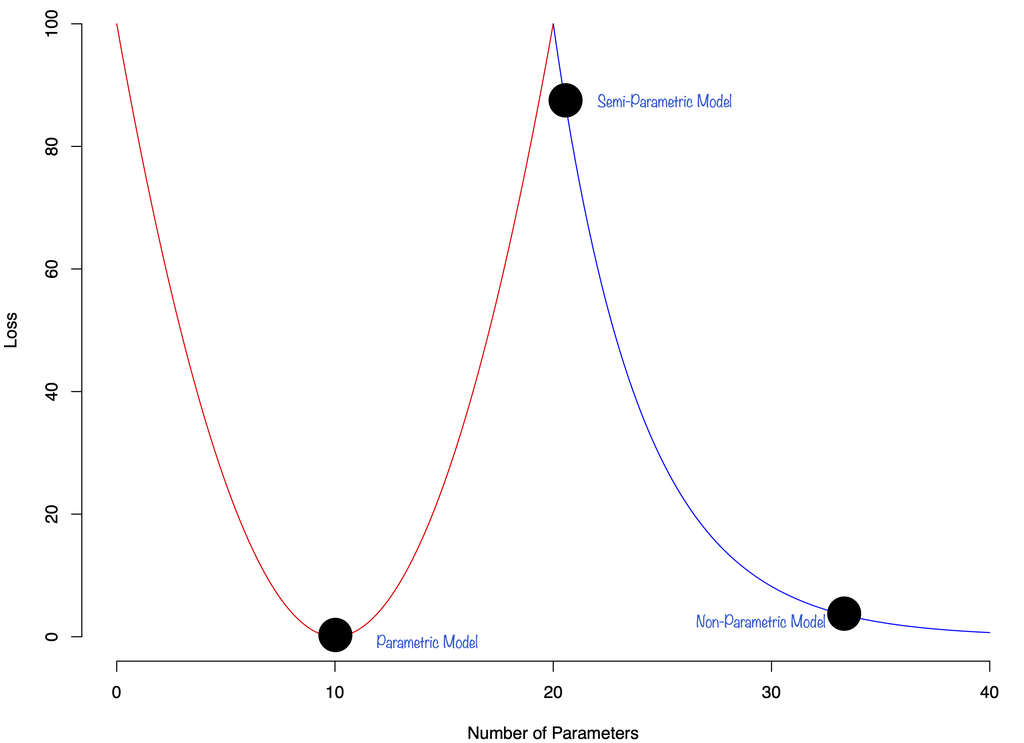

Stylized double descent curve showing three regimes

The curve shows two distinct phases:

- First descent follows classical bias-variance trade-off
- Second descent occurs in over-parameterized regime
- Peak occurs at interpolation threshold where $p = n$

## Why Double Descent Matters

Inspect the actual experiment. A named regime or curve is not a universal result. Separate interpolation, noise fitting, extrapolation, basis conditioning and floating-point effects.

Modern machine learning practice increasingly uses over-parameterized models with parameters far exceeding the number of observations. Examples include large language models, image processing networks, and generative AI methods.

**Key insights:**

- More parameters don’t necessarily mean worse generalization
- Interpolators achieving zero training error can still generalize well
- Implicit regularization from minimum-norm solutions helps
- Traditional model selection may be unnecessarily conservative

**Practical implication:** Instead of carefully tuning to find optimal complexity, over-parameterize and get good performance automatically!

## Double Descent Example: Polynomial Regression

Inspect the actual experiment. A named regime or curve is not a universal result. Separate interpolation, noise fitting, extrapolation, basis conditioning and floating-point effects.

We demonstrate double descent using polynomial regression with a sinusoidal target function $f(x) = \sin(5x)$.

**Setup:**

- Only $n = 20$ training observations from $[-1, 1]$
- Gaussian noise with $\sigma = 0.3$
- Fit polynomials of degree $d = 1, 2, \ldots, 50$
- Use Legendre polynomial basis for numerical stability
- Estimate coefficients using Moore-Penrose pseudoinverse

Small sample size is crucial for observing double descent, creating a regime where parameters can substantially exceed observations.

## Polynomial Fits Across Complexity Levels

Inspect the actual experiment. A named regime or curve is not a universal result. Separate interpolation, noise fitting, extrapolation, basis conditioning and floating-point effects.

Original code uses its source lesson’s setup and data. Saved outputs, where shown, were not rerun for this edition.

**Show original python code 1**

```python
#| code-fold: true
#| code-summary: "Python Setup"
import numpy as np
import matplotlib.pyplot as plt

np.random.seed(42)

def sin_func(x):
    return np.sin(5*x)

G = np.polynomial.legendre.legvander

def poly(pts, beta, d):
    return G(pts, d).dot(beta)

n = 20
sigma = 0.3
a, b = -1, 1

ground_truth = sin_func
x = np.linspace(a, b, n)
y = ground_truth(x) + sigma * np.random.normal(size=n)
xdense = np.linspace(a, b, 100)
ygt = ground_truth(xdense)

def fit(d):
    betaHat = np.linalg.pinv(G(x, d)).dot(y)
    mseos = np.sqrt(np.mean((G(xdense, d).dot(betaHat) - ygt)**2))
    mseis = np.sqrt(np.mean((G(x, d).dot(betaHat) - y)**2))
    return betaHat, mseos, mseis

def run(d, ax):
    betaHat, mseos, mseois = fit(d)
    ax.plot(xdense, ygt, label='ground-truth')
    ax.scatter(x, y, c='r', label='samples')
    ax.plot(xdense, poly(xdense, betaHat, d), label='model')
    ax.set_ylim(-2, 2)
    ax.axis('off')
    ax.legend()
    ax.set_title('d=%d, MSE: Test=%.2f, Train=%.2f' % (d, mseos, mseois))
```

**Show original python code 2**

```python
#| code-fold: true
#| label: fig-double-descent-grid
#| fig-cap: "Four representative polynomial degrees showing double descent phases"

fig, axes = plt.subplots(2, 2, figsize=(12, 10))
fig.suptitle('Double Descent: Polynomial Regression', fontsize=16)

run(1, axes[0, 0])   # Underparameterized
run(5, axes[0, 1])   # Classical optimum
run(20, axes[1, 0])  # Interpolation threshold
run(50, axes[1, 1])  # Over-parameterized

plt.tight_layout()
plt.show()
```

## Understanding the Four Regimes

Inspect the actual experiment. A named regime or curve is not a universal result. Separate interpolation, noise fitting, extrapolation, basis conditioning and floating-point effects.

**Degree 1 (Underparameterized):** Linear model too simple to capture oscillatory sine function. High bias, poor fit to both training and test data.

**Degree 5 (Classical Optimum):** Sweet spot of traditional bias-variance tradeoff. Sufficient complexity to capture main features without severe overfitting.

**Degree 20 (Interpolation Threshold):** Exactly as many parameters as observations, enabling perfect interpolation. Wild oscillations between data points lead to poor generalization.

**Degree 50 (Over-parameterized):** Despite having far more parameters than observations, achieves better test performance than interpolating model. This is the double descent effect!

## The Complete MSE Curve

Inspect the actual experiment. A named regime or curve is not a universal result. Separate interpolation, noise fitting, extrapolation, basis conditioning and floating-point effects.

Original code uses its source lesson’s setup and data. Saved outputs, where shown, were not rerun for this edition.

**Show original python code 1**

```python
#| code-fold: true
#| label: fig-mse-curve
#| fig-cap: "Training and test MSE across polynomial degrees showing double descent"

nd = 50
mse_test = np.zeros(nd)
mse_train = np.zeros(nd)

for d in range(1, nd):
    betaHat, mseos, mseois = fit(d)
    mse_test[d] = mseos
    mse_train[d] = mseois

fig, ax1 = plt.subplots(figsize=(10, 6))
ax1.set_xlabel('Polynomial Degree (Model Complexity)', fontsize=12)
ax1.set_ylabel('log10(MSE)', color='black', fontsize=12)
ax1.plot(np.log10(mse_test), color='blue', linewidth=2, label='Test MSE')
ax2 = ax1.twinx()
ax2.set_ylabel('log10(Train MSE)', color='red', fontsize=12)
ax2.plot(np.log10(mse_train), color='red', linewidth=2, label='Train MSE')
ax2.tick_params(axis='y', labelcolor='red')

lines1, labels1 = ax1.get_legend_handles_labels()
lines2, labels2 = ax2.get_legend_handles_labels()
ax1.legend(lines1 + lines2, labels1 + labels2, loc='upper right')
plt.title('Double Descent Phenomenon in Polynomial Regression')
plt.tight_layout()
plt.show()
```

The test error (blue line) exhibits characteristic double descent shape with three phases:

**Classical Regime** ($d < 5$): Increasing model complexity reduces both bias and test error. Traditional understanding of bias-variance tradeoff applies.

**Interpolation Crisis** ($d \approx n = 20$): Test error peaks dramatically as model perfectly fits training data while generalizing poorly. This is where classical theory predicts catastrophic overfitting.

**Over-parameterized Regime** ($d > 30$): Test error decreases again! Extreme over-parameterization leads to improved generalization despite ability to memorize training data.

The double descent phenomenon arises from **implicit regularization** effects of minimum-norm solutions in over-parameterized settings.

When $d > n$, the pseudoinverse solution corresponds to minimum $\ell_2$-norm coefficients among all possible interpolating solutions. This implicit bias toward simpler functions leads to surprisingly good generalization.

**Mathematical insight:** Among infinitely many solutions that perfectly fit the data, we automatically select the one with smallest coefficients, providing implicit regularization without explicit penalties.

**Connection to deep learning:** Similar implicit regularization occurs in over-parameterized neural networks through gradient descent dynamics.

## Bayesian Perspective on Double Descent

Inspect the actual experiment. A named regime or curve is not a universal result. Separate interpolation, noise fitting, extrapolation, basis conditioning and floating-point effects.

Double descent has a natural Bayesian interpretation and is not in conflict with Occam’s razor that Bayesian models possess.

**Occam’s Razor:** Bayesian methods naturally favor simpler models through the marginal likelihood, penalizing complexity via corrections like BIC.

**Reconciliation:** Even though Bayesian methods shift posterior toward lower-complexity models, highly parameterized Bayesian models can have good risk properties due to the conditional prior of parameters given the model.

The key is that over-parameterized models don’t necessarily have high effective complexity when properly regularized (implicitly or explicitly).

## Implications for Practice

The double descent phenomenon has significant practical implications for modern machine learning:

**Model selection strategy:** Given that finding the “sweet spot” is time-consuming and computationally expensive, over-parameterization provides good performance automatically without careful tuning.

**Generality:** Observed across wide range of models including deep neural networks, random forests, kernel methods, and linear models.

**Challenge to intuition:** Classical statistical wisdom about model complexity doesn’t apply in contemporary settings with over-parameterized models.

**Modern AI success:** Helps explain why massive models (GPT, BERT, etc.) generalize well despite billions of parameters.

## The Normal Means Problem

**Setup:**
$$y_i \mid \theta_i \sim N(\theta_i, \sigma^2), \quad i=1,\ldots,p, \quad p > 2$$

**Goal:** Estimate $\theta = (\theta_1, \ldots, \theta_p)$ under squared loss
$$\mathcal{L}(\theta, \hat{\theta}) = \sum_{i=1}^p (\theta_i - \hat{\theta}_i)^2$$

**MLE:** $\hat{\theta}_i^{MLE} = y_i$

**Risk:** $R(\theta,\hat{\theta}^{MLE}) = p\sigma^2$ (constant!)

## Shocking Result

For $p \geq 3$, the MLE is **inadmissible** under squared error loss!

There exist estimators with **uniformly lower risk** than MLE.

**James-Stein Estimator:**
$$\hat{\theta}_i^{JS} = \left(1 - \frac{(p-2)\sigma^2}{\|y\|^2}\right) y_i$$

**Risk:** $R(\theta, \hat{\theta}^{JS}) < R(\theta, \hat{\theta}^{MLE})$ for all $\theta$

## Why James-Stein Works

- **Shrinkage**: Pulls estimates toward zero (or overall mean)
- **Borrowing strength**: Uses information across components
- **Global regularization**: Single shrinkage parameter
- **Bias-variance trade-off**: Small bias for large variance reduction

**Key insight:** Multivariate estimation is easier than univariate when using appropriate shrinkage!

## Baseball Example: James-Stein in Action

Original code uses its source lesson’s setup and data. Saved outputs, where shown, were not rerun for this edition.

## Empirical Bayes Interpretation

**Hierarchical Model:**
$$\begin{aligned}
y_i \mid \theta_i &\sim N(\theta_i, \sigma^2) \\
\theta_i \mid \mu, \tau^2 &\sim N(\mu, \tau^2)
\end{aligned}$$

**Empirical Bayes:** - Estimate $\hat{\mu} = \bar{y}$ - Estimate $\hat{\tau}^2$ from data - Use in posterior mean calculation

**Result:** Closely related to James-Stein estimator

## Appendix: Mathematical Details

**James-Stein Risk Calculation:**
$$R(\theta, \hat{\theta}^{JS}) = p\sigma^2 - (p-2)\sigma^2 \mathbb{E}\left[\frac{1}{\|\theta + \epsilon\|^2/\sigma^2}\right]$$

**Horseshoe Posterior Mean:**
$$\mathbb{E}[\theta_i \mid y_i] = \left(1 - \kappa_i\right) \cdot 0 + \kappa_i \cdot y_i$$
where $\kappa_i$ depends on $\tau$ and $y_i$

## Appendix: Simulation Study

Original code uses its source lesson’s setup and data. Saved outputs, where shown, were not rerun for this edition.

## Appendix: Bayesian Computation

Original code uses its source lesson’s setup and data. Saved outputs, where shown, were not rerun for this edition.

## Double Descent Example

Inspect the actual experiment. A named regime or curve is not a universal result. Separate interpolation, noise fitting, extrapolation, basis conditioning and floating-point effects.

Original code uses its source lesson’s setup and data. Saved outputs, where shown, were not rerun for this edition.

**Show original python code 1**

```python
#| echo: false
import numpy as np
import numpy.random as rand
import numpy.linalg as la
import matplotlib.pyplot as plt

# Set random seed for reproducibility
np.random.seed(42)
# Functions
def arctan_gt(x):
    return np.arctan(5*x)

def cubic_gt(x):
    return poly(x, np.array([0, -1, 0, 1]), 3)

def relu(x):
    return x*(x >= 0)

def sin(x):
    return np.sin(5*x)

def Vand(x, d):
    """Vandermonde matrix for pts x, to degree d"""
    X = np.array([x**i for i in range(0, d+1)]).T
    return X
```

## Polynomial Regression Setup

Inspect the actual experiment. A named regime or curve is not a universal result. Separate interpolation, noise fitting, extrapolation, basis conditioning and floating-point effects.

Original code uses its source lesson’s setup and data. Saved outputs, where shown, were not rerun for this edition.

**Show original python code 1**

```python
#| code-fold: true

n = 20  # number of samples
sigma = 0.3  # stdev of noise
a = -1
b = 1  # range of x values
# Use Legendre polynomial basis by default
G = np.polynomial.legendre.legvander

def poly(pts, beta, d):
    return G(pts, d).dot(beta)

# Initialize data
ground_truth = sin
x = np.linspace(a, b, n)
y = ground_truth(x) + sigma * np.random.normal(size=n)
xdense = np.linspace(a, b, 100)
ygt = ground_truth(xdense)

# Core functions
def solve_reg(A, y, lamb):
    return la.solve(A.T.dot(A) + lamb * np.identity(A.shape[1]), A.T.dot(y))

def fit(d):
    betaHat = la.pinv(G(x, d)).dot(y)
    mseos = np.sqrt(np.mean((G(xdense, d).dot(betaHat) - ygt)**2))
    mseis = np.sqrt(np.mean((G(x, d).dot(betaHat) - y)**2))
    return betaHat, mseos, mseis

def run(d, ax):
    """Compute the regressor for degree d, and plot the solution."""
    betaHat, mseos, mseois = fit(d)
    ax.plot(xdense, ygt, label='ground-truth')
    ax.scatter(x, y, c='r', label='samples')
    ax.plot(xdense, poly(xdense, betaHat, d), label='model')
    ax.set_ylim(-2, 2)
    ax.axis('off')
    ax.legend()
    ax.set_title('d=%d, MSE: Test=%.2f, Train=%.2f' % (d, mseos, mseois))
```

## Double Descent Results

Inspect the actual experiment. A named regime or curve is not a universal result. Separate interpolation, noise fitting, extrapolation, basis conditioning and floating-point effects.

Original code uses its source lesson’s setup and data. Saved outputs, where shown, were not rerun for this edition.

**Show original python code 1**

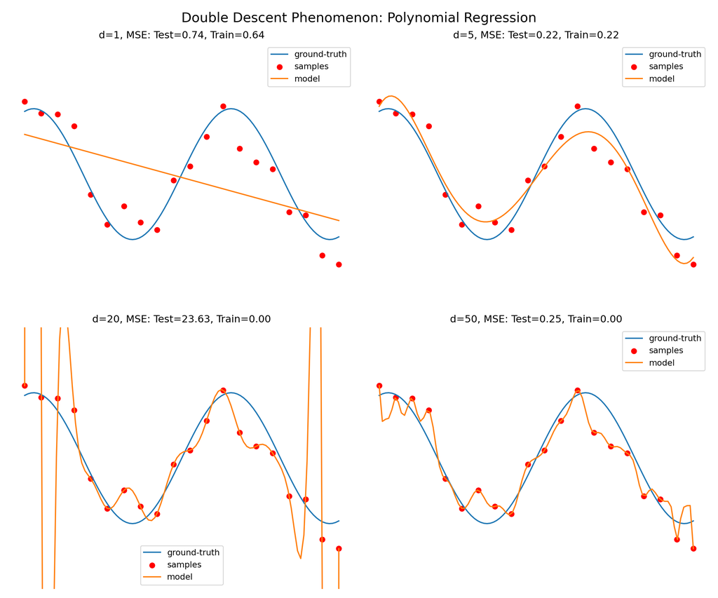

Original saved output: Double Descent Results

```python
#| code-fold: true
#| label: fig-double-descent-grid
#| fig-cap: "Double Descent Phenomenon: Polynomial Regression with Different Degrees"

# Create 2x2 subplot grid
fig, axes = plt.subplots(2, 2, figsize=(12, 10))
fig.suptitle('Double Descent Phenomenon: Polynomial Regression', fontsize=16)

# Plot each degree in its respective subplot
run(1, axes[0, 0])   # Top left
run(5, axes[0, 1])   # Top right
run(20, axes[1, 0])  # Bottom left
run(50, axes[1, 1])  # Bottom right

plt.tight_layout()
plt.show()
```

## MSE Curve Analysis

Inspect the actual experiment. A named regime or curve is not a universal result. Separate interpolation, noise fitting, extrapolation, basis conditioning and floating-point effects.

Original code uses its source lesson’s setup and data. Saved outputs, where shown, were not rerun for this edition.

**Show original python code 1**

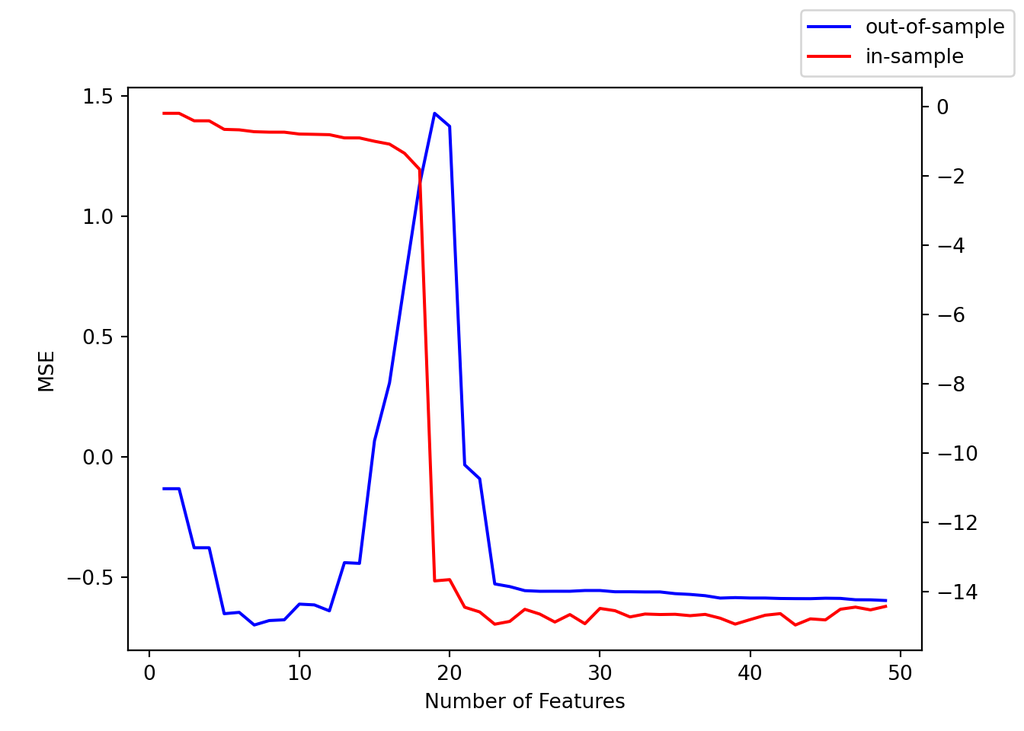

Original saved output: MSE Curve Analysis

```python
#| code-fold: true
#| label: fig-mse-curve
#| fig-cap: "Bias-Variance Trade-off: Training and Test MSE vs Model Complexity"

# Generate MSE data for different polynomial degrees
nd = 50
mse1 = np.zeros(nd)  # Test MSE
mse2 = np.zeros(nd)  # Train MSE

for d in range(1, nd):
    betaHat, mseos, mseois = fit(d)
    mse1[d] = mseos
    mse2[d] = mseois
fig, ax1 = plt.subplots()
ax1.set_xlabel('Number of Features')
ax1.set_ylabel('MSE', color='black')
ax1.plot(np.log10(mse1), color='blue', label='out-of-sample')
ax2 = ax1.twinx()
ax2.plot(np.log10(mse2), color='red', label='in-sample')
fig.legend()
```

## Double Descent Phases

Inspect the actual experiment. A named regime or curve is not a universal result. Separate interpolation, noise fitting, extrapolation, basis conditioning and floating-point effects.

1. **Classical Regime** ($d < 5$): Traditional bias-variance tradeoff
2. **Interpolation Crisis** ($d \approx n = 20$): Test error peaks at perfect fit
3. **Over-parameterized Regime** ($d > 30$): Test error decreases with extreme over-parameterization

**Key insight**: Implicit regularization through minimum-norm solutions

## Project build checkpoint

- Show the baseline and one alternative under the agreed evaluation design.
- Explain the strongest check that could have failed.
- Identify one remaining uncertainty that matters to the recommendation.

Why should feature units matter to ridge?

Why would selecting $\lambda$ using training error defeat the purpose?

What remains when the penalty is huge and the intercept is unpenalized?

How would you distinguish a poor constraint from an optimizer that failed?

## Self-practice

- Classification. Move the intercept and one coefficient, and fit a straight logit to the circle data. Compare thresholds 0.3, 0.5, and 0.8. For scores $\log 3,\log 2,0$, compute the three probabilities and the loss of the first class, then add 1,000 to every score.
- Evaluation. Fit polynomial degrees 1, 3, and 12. Compare training and validation error with the constant baseline. Then add a feature recorded after the outcome.
- Regularization. Fit penalties 0, 0.01, 1, and 100. Add a little noise to the training responses and compare a weak penalty with a moderate one.